# Projet de Statistical Learning

KAMGA BOPDA Davy Romaric

2025-05-19

# 1 **Introduction**

Dans le cadre de ce projet, nous nous intéressons à la modélisation de la propension d’un client à souscrire une **assurance voyage** proposée par une agence de tourisme. L’objectif est de construire un modèle prédictif capable d’identifier les clients susceptibles d’accepter cette offre, en se basant sur leurs caractéristiques sociodémographiques, leur comportement de voyage et leur historique médical.

La problématique se fonde sur un jeu de données accessible publiquement via la plateforme **Kaggle**. Il s’agit d’une base regroupant les données de **près de 2 000 clients** ayant été contactés en 2019 lors du lancement d’une nouvelle assurance voyage incluant une **couverture Covid**. L’entreprise souhaite désormais tirer parti de cet historique pour affiner ses actions marketing et cibler efficacement les futurs clients.

La **target** (**TravelInsurance**) est binaire : elle indique si un client a souscrit (1) ou non (0) à l’assurance voyage proposée. Elle est donc modélisée à l’aide d’une **loi binomiale**, associée à une **fonction de lien logit**, conformément aux approches classiques en classification. Ce cadre est cohérent avec les méthodes d’arbres de classification comme **CART**, **Random Forests** et **Gradient Boosting**, qui seront testées et comparées dans ce projet.

Les variables explicatives disponibles dans le jeu de données incluent notamment :

1. l’âge du client (**Age**),
2. son secteur d’activité(**Employment Type**),
3. son niveau d’études (diplômé universitaire ou non) (**GraduateOrNot**),
4. son revenu annuel (en roupies indiennes) (**AnnualIncome**),
5. la taille de son foyer familial (**FamilyMembers**),
6. la présence d’une maladie chronique (**ChronicDiseases**),
7. sa fréquence de voyage (voyageur fréquent ou non) (**FrequentFlyer**),
8. s’il a déjà voyagé à l’étranger (**EverTravelledAbroad**).

Toutes ces informations sont susceptibles d’influencer la décision du client face à l’offre d’assurance, ce qui justifie leur intégration dans le modèle.

L’analyse sera précédée d’une **analyse exploratoire des données**, principalement réalisée à l’aide du package `ggplot2`, afin de visualiser les relations entre la variable réponse et les covariables, détecter d’éventuelles anomalies et comprendre les structures de dépendance.

Le choix du cadre binomial logit est soutenu par les références suivantes :

- Frees, E. W. (2010). *Regression Modeling with Actuarial and Financial Applications*. Cambridge University Press.

Ainsi, ce travail vise à sélectionner le **modèle d’arbre optimal** permettant une prédiction fiable de l’adhésion à l’assurance voyage, tout en garantissant une bonne capacité de généralisation.

## 1.1 **Importation des packages du projet**

```r
library(readr)
library(ggplot2)
library(scales)
library(rpart)
library(rpart.plot)
library(caret)
library(pdp)
library(gridExtra)
library(pROC)
library(rlang)
library(dplyr)
library(randomForest)
library(ranger)
library(gbm)
library(reshape2)
```

## 1.2 **Importation du fichier et prétraitement du jeu de données**

```r
base <- read_csv(
  "C:/Users/LGC/Desktop/Cours actuariat/LACTU2310-Statistical learning/Projet/archive (2)/TravelInsurancePrediction.csv",
  show_col_types = FALSE
) |>
  select(-1)
```

On vérifie ici que la base a été correctement importée en affichant les premières lignes du jeu de données.

```r
head(base)
```

```
## # A tibble: 6 × 9
##     Age `Employment Type`            GraduateOrNot AnnualIncome FamilyMembers
##   <dbl> <chr>                        <chr>                <dbl>         <dbl>
## 1    31 Government Sector            Yes                 400000             6
## 2    31 Private Sector/Self Employed Yes                1250000             7
## 3    34 Private Sector/Self Employed Yes                 500000             4
## 4    28 Private Sector/Self Employed Yes                 700000             3
## 5    28 Private Sector/Self Employed Yes                 700000             8
## 6    25 Private Sector/Self Employed No                 1150000             4
## # ℹ 4 more variables: ChronicDiseases <dbl>, FrequentFlyer <chr>,
## #   EverTravelledAbroad <chr>, TravelInsurance <dbl>
```

```r
str(base)
```

```
## tibble [1,987 × 9] (S3: tbl_df/tbl/data.frame)
##  $ Age                : num [1:1987] 31 31 34 28 28 25 31 31 28 33 ...
##  $ Employment Type    : chr [1:1987] "Government Sector" "Private Sector/Self Employed" "Private Sector/Self Employed" "Private Sector/Self Employed" ...
##  $ GraduateOrNot      : chr [1:1987] "Yes" "Yes" "Yes" "Yes" ...
##  $ AnnualIncome       : num [1:1987] 400000 1250000 500000 700000 700000 1150000 1300000 1350000 1450000 800000 ...
##  $ FamilyMembers      : num [1:1987] 6 7 4 3 8 4 4 3 6 3 ...
##  $ ChronicDiseases    : num [1:1987] 1 0 1 1 1 0 0 0 1 0 ...
##  $ FrequentFlyer      : chr [1:1987] "No" "No" "No" "No" ...
##  $ EverTravelledAbroad: chr [1:1987] "No" "No" "No" "No" ...
##  $ TravelInsurance    : num [1:1987] 0 0 1 0 0 0 0 1 1 0 ...
```

Nous observons ici que notre jeu de données comprend **1987** individus et **9** variables indépendantes, avec des informations sur le type de chaque variable. Nous remarquons que la variable **ChronicDiseases** est numérique, mais doit être retraitée car elle est binaire : 1 indique la présence d’une maladie chronique, tandis que 0 indique son absence. De plus, la variable **FamilyMembers** est de type discret. La variable cible, **TravelInsurance**, est également numérique, mais est catégorique binaire ; nous veillerons à la recoder dans la section suivante.

```r
base$TravelInsurance <- ifelse(base$TravelInsurance == 1, "Yes", "No")
base$ChronicDiseases <- ifelse(base$ChronicDiseases == 1, "Yes", "No")
base$FamilyMembers <- factor(base$FamilyMembers)
```

## 1.3 **Analyse des valeurs manquantes**

```r
colSums(is.na(base)) / nrow(base) * 100
```

```
##                 Age     Employment Type       GraduateOrNot        AnnualIncome
##                   0                   0                   0                   0
##       FamilyMembers     ChronicDiseases       FrequentFlyer EverTravelledAbroad
##                   0                   0                   0                   0
##     TravelInsurance
##                   0
```

Nous observons que les variables de notre jeu de données ne présentent aucune valeur manquante.

# 2 **Analyse descriptive**

```r
continuous_vars <- names(base)[sapply(base, is.numeric)]

categorical_vars <- names(base)[sapply(base, function(x) is.character(x) || is.factor(x))]

cat("Les variables categorielles sont : ",categorical_vars,"\n\n")
```

```
## Les variables categorielles sont :  Employment Type GraduateOrNot FamilyMembers ChronicDiseases FrequentFlyer EverTravelledAbroad TravelInsurance
```

```r
cat("Les variables continues sont : ",continuous_vars,"\n")
```

```
## Les variables continues sont :  Age AnnualIncome
```

## 2.1 **Analyse univariée des variables continues**

```r
summary(base[continuous_vars])
```

```
##       Age         AnnualIncome
##  Min.   :25.00   Min.   : 300000
##  1st Qu.:28.00   1st Qu.: 600000
##  Median :29.00   Median : 900000
##  Mean   :29.65   Mean   : 932763
##  3rd Qu.:32.00   3rd Qu.:1250000
##  Max.   :35.00   Max.   :1800000
```

Les résultats de cette analyse indiquent que 50 % des individus ont un âge supérieur à 29 ans (médiane = 29), et 75 % ont un âge inférieur à 32 ans. De plus, l’âge moyen est de 29,65 ans, avec le plus âgé ayant 35 ans et le plus jeune, 25 ans. Concernant la variable **AnnualIncome**, les analyses révèlent que 50 % des individus ont un revenu annuel inférieur à 900 000 roupies (médiane = 900 000), tandis que le revenu moyen s’élève à 932 763 roupies. Le revenu le plus élevé atteint 1 800 000 roupies.

**NB :** Les montants sont exprimés en roupies indiennes.

## 2.2 **Analyse univariée des variables catégorielles**

```r
plot_categorical_distribution <- function(data, variable) {
  var_sym <- sym(variable)

  ggplot(data, aes(x = !!var_sym)) +
    geom_bar(aes(y = ..count.. / sum(..count..)), fill = "steelblue") +
    geom_text(stat = "count",
              aes(label = scales::percent(..count.. / sum(..count..)),
                  y = ..count.. / sum(..count..)),
              vjust = -0.5) +
    scale_y_continuous(labels = percent_format(accuracy = 1), limits = c(0, 1.1)) +
    labs(title = paste("Distribution de", variable),
         x = variable,
         y = "Pourcentage") +
    theme_minimal()
}
```

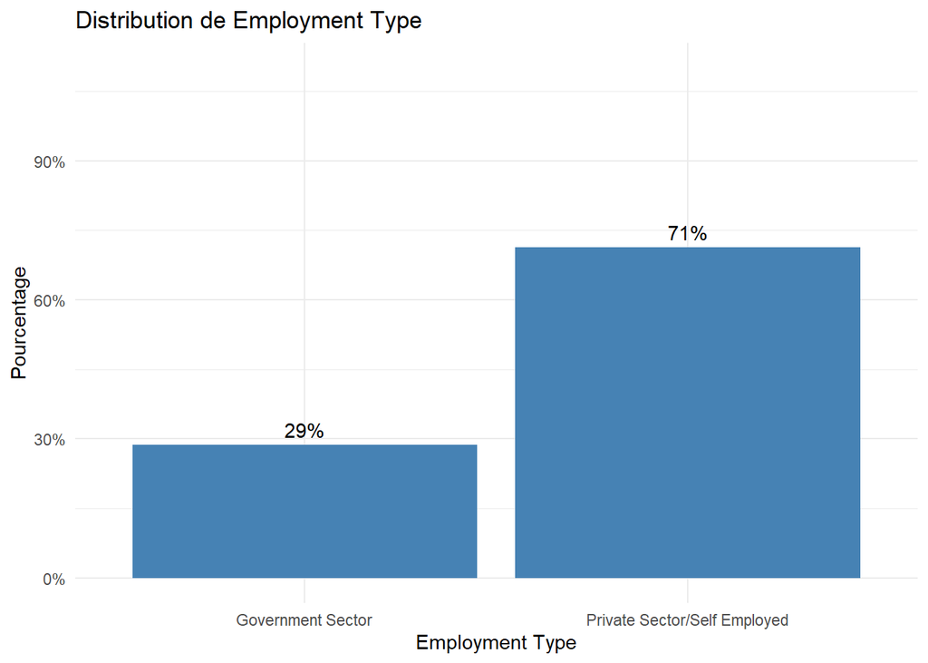

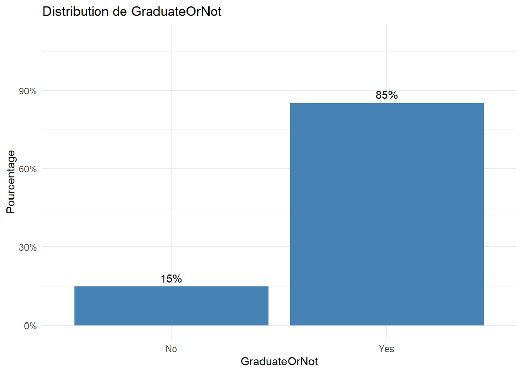

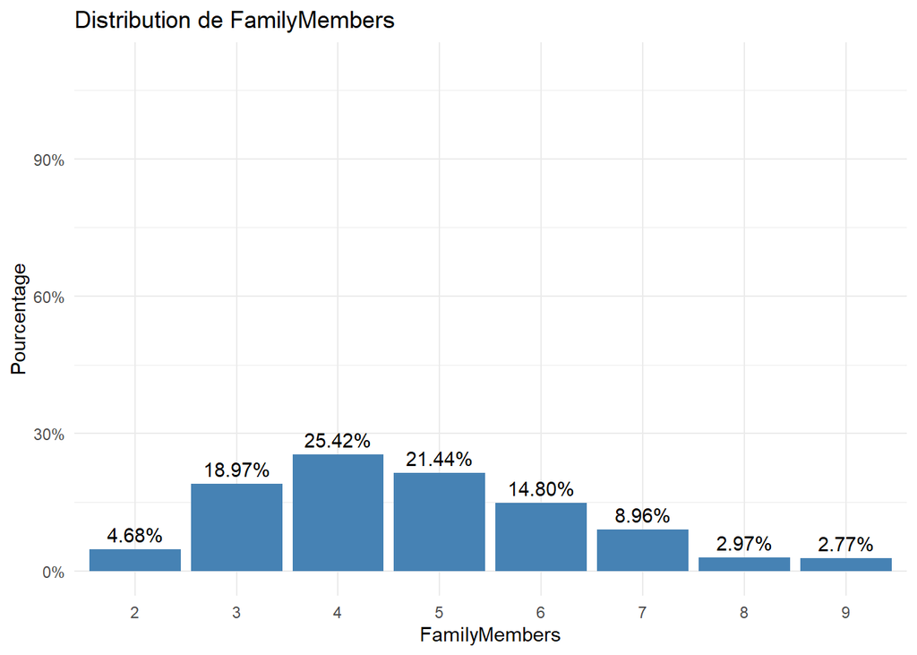

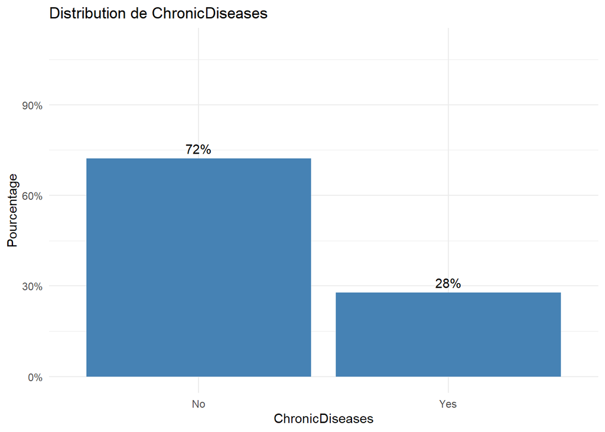

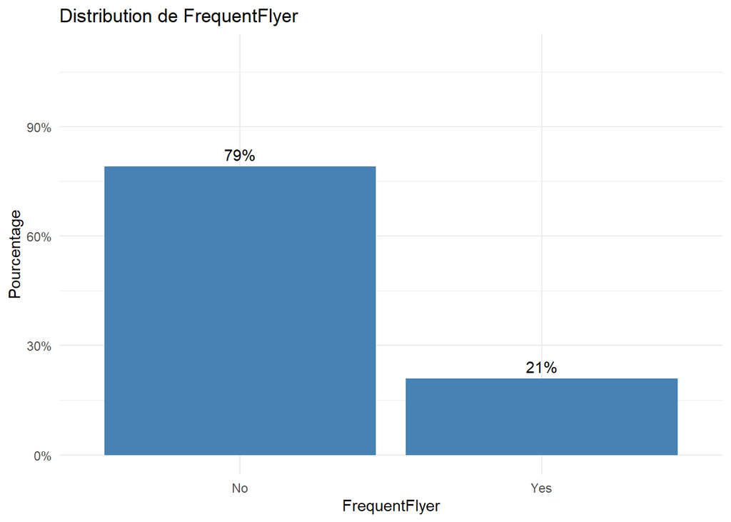

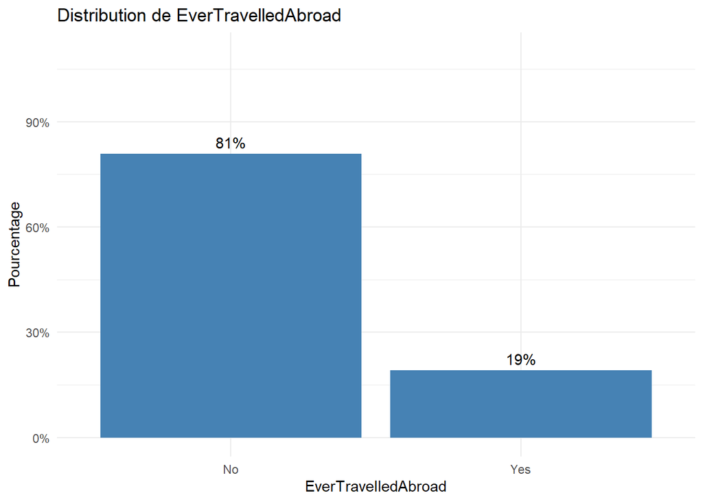

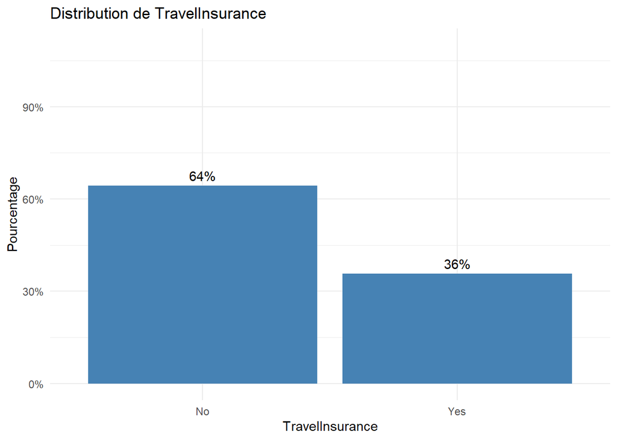

```r
for (var in categorical_vars) {
  print(plot_categorical_distribution(base, var))
}
```

- **Secteur d’emploi** : 71% des individus travaillent dans le **secteur privé** ou sont **travailleurs indépendants**, contre 29% employés par le **gouvernement**.
- **Niveau d’études** : 85% des individus détiennent un **diplôme universitaire**, tandis que 15% n’en ont pas.
- **Fréquence de voyage** : 79% **ne voyagent pas fréquemment**, contre 21% qui **voyagent régulièrement**.
- **Voyage à l’étranger** : 81% n’ont **jamais voyagé à l’étranger**, tandis que 19% l’ont déjà fait.
- **Maladies chroniques** : 72% des individus **ne souffrent d’aucune maladie chronique**, contre 28% atteints d’au moins une.
- **Structure familiale** : Les familles de **4 membres** sont les plus fréquentes (**25,42%**), suivies de près par celles de **5 membres** (**21,44%**). Ces deux groupes représentent **près de 47%** de l’échantillon.
- **Souscription à l’assurance voyage** : Seuls **36% des clients** ont **souscrit** à l’assurance voyage, tandis que **64%** ne l’ont **pas fait**, ce qui suggère que **près de 2 clients sur 3** refusent l’offre.

## 2.3 **Analyse bi-variée**

### 2.3.1 **Croisement entre variables continues et la variable cible**

```r
boxplot_croisement <- function(data, variable) {
  var_sym <- sym(variable)

  ggplot(data, aes(x = TravelInsurance, y = !!var_sym, fill = TravelInsurance)) +
    geom_boxplot() +
    labs(title = paste("Boxplot de", variable, "par rapport a TravelInsurance"),
         x = "Propension a voyager ",
         y = variable) +
    theme_minimal() +
    theme(axis.text.x = element_text(angle = 45, hjust = 1)) +
    scale_fill_manual(values = c("blue", "green"))
}
```

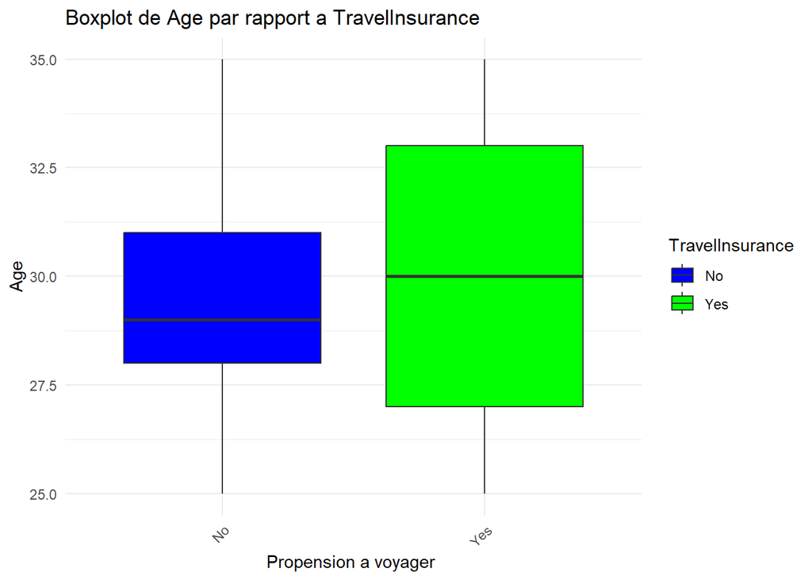

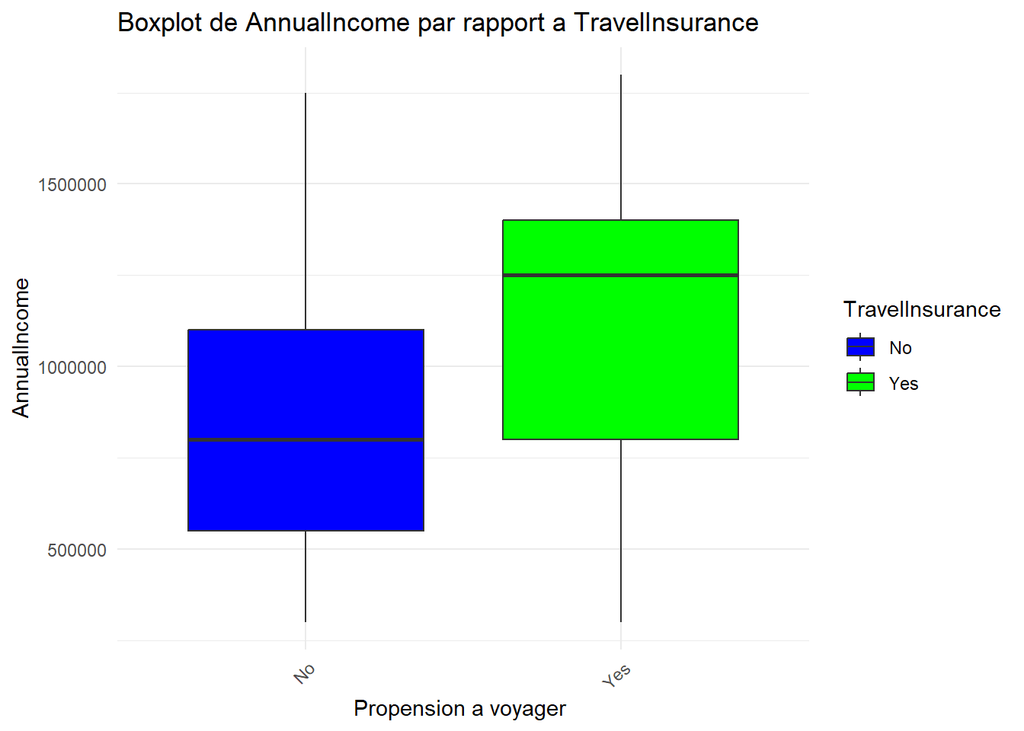

```r
for (var in continuous_vars) {
  print(boxplot_croisement(base, var))
}
```

Les résultats montrent que **l’âge** joue un rôle important dans la souscription à l’assurance voyage : les individus **plus âgés** semblent **davantage enclins à souscrire**, contrairement aux plus jeunes. Cela suggère une **corrélation positive** entre l’âge et la probabilité de souscription.

Une tendance similaire est observée pour le **revenu annuel** : les personnes disposant de **revenus plus élevés** sont **significativement plus susceptibles** de souscrire à l’assurance voyage. Cette variable apparaît donc comme un **facteur discriminant majeur**.

Par conséquent, **l’âge** et le **revenu annuel** devraient être **retenus comme prédicteurs clés** dans les modèles de classification (arbre de décision, random forest, bagging, gradient boosting) afin d’améliorer la **performance prédictive**.

### 2.3.2 **Croisement entre variables catégorielles et la variable cible**

```r
categorical_vars <- setdiff(categorical_vars, "TravelInsurance")

barplot_croisement <- function(data, var_cat) {
  var_sym <- sym(var_cat)

  # Calcul des proportions
  prop_df <- data %>%
    group_by(!!var_sym, TravelInsurance) %>%
    summarise(count = n(), .groups = "drop") %>%
    group_by(!!var_sym) %>%
    mutate(proportion = 100 * count / sum(count))

  # Création du barplot
  ggplot(prop_df, aes(x = !!var_sym, y = proportion, fill = TravelInsurance)) +
    geom_bar(stat = "identity", position = "dodge") +
    geom_text(aes(label = paste0(round(proportion, 1), "%")),
              position = position_dodge(width = 0.9),
              vjust = -0.25, size = 3) +
    scale_y_continuous(limits = c(0, 110), labels = function(x) paste0(x, "%")) +
    labs(title = paste("Proportion de TravelInsurance selon", var_cat),
         x = var_cat, y = "Proportion (%)", fill = "TravelInsurance") +
    theme_minimal() +
    theme(axis.text.x = element_text(angle = 45, hjust = 1))
}
```

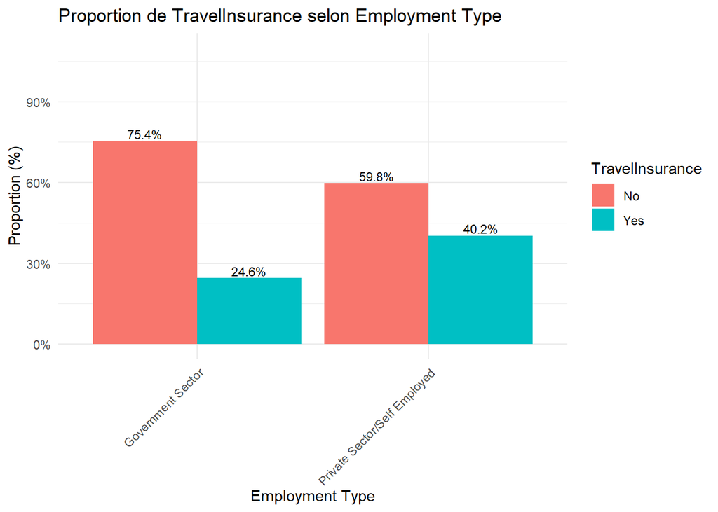

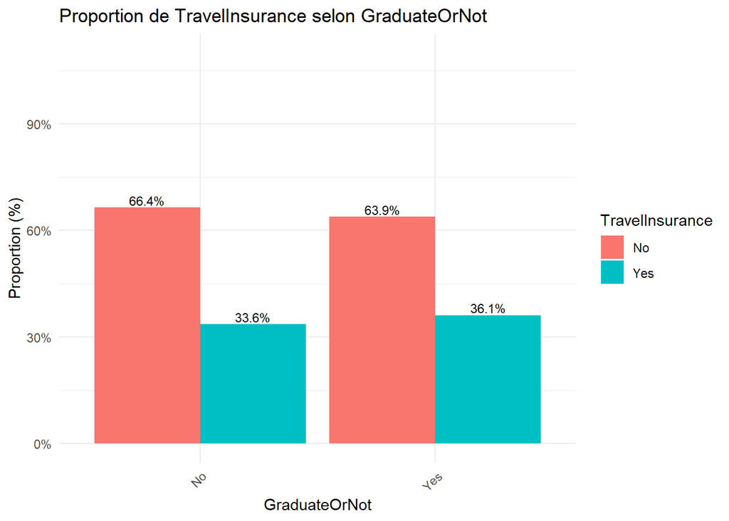

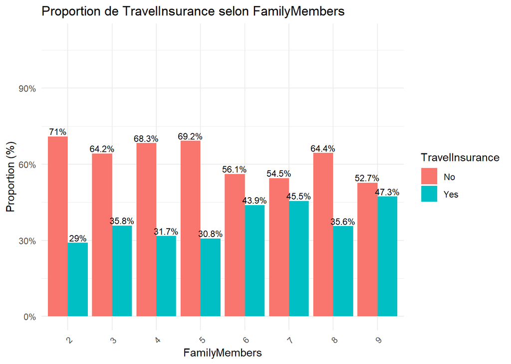

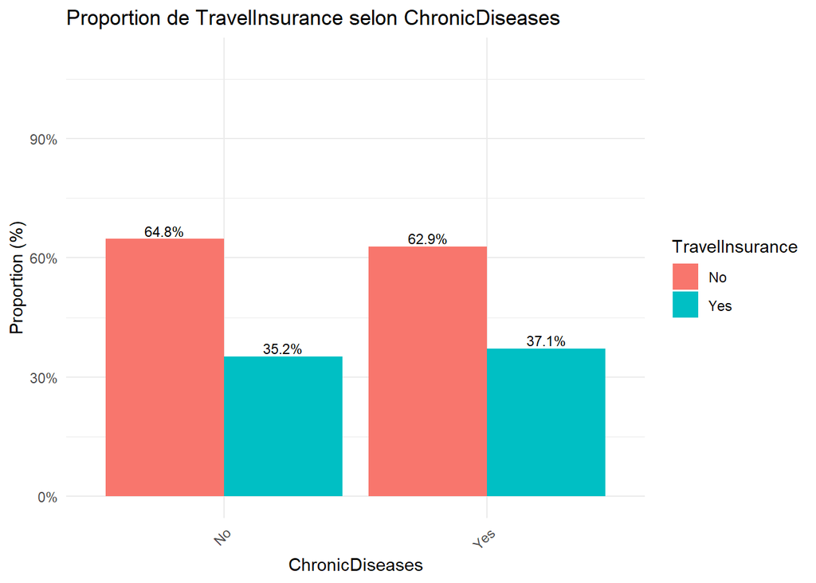

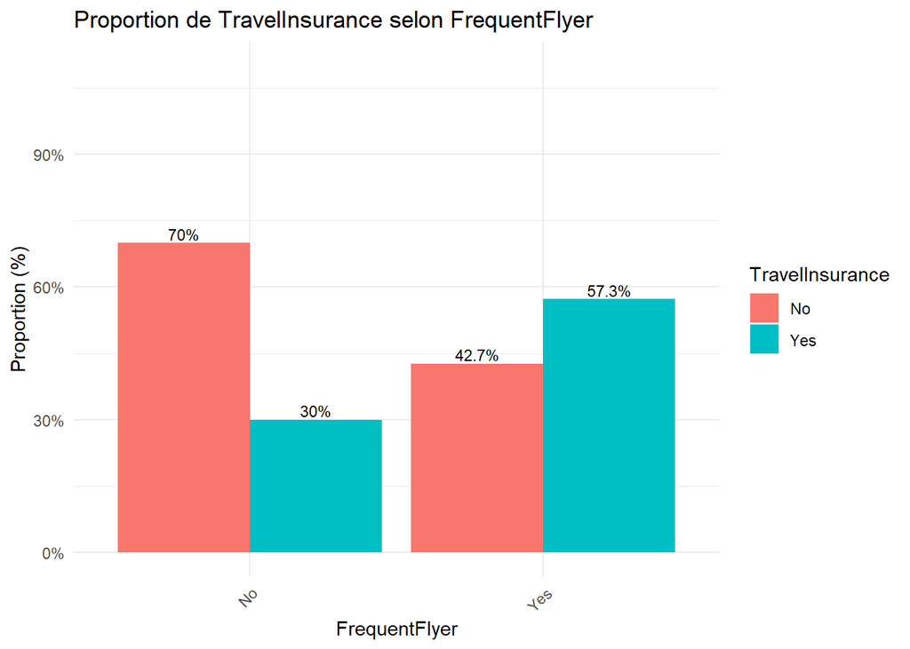

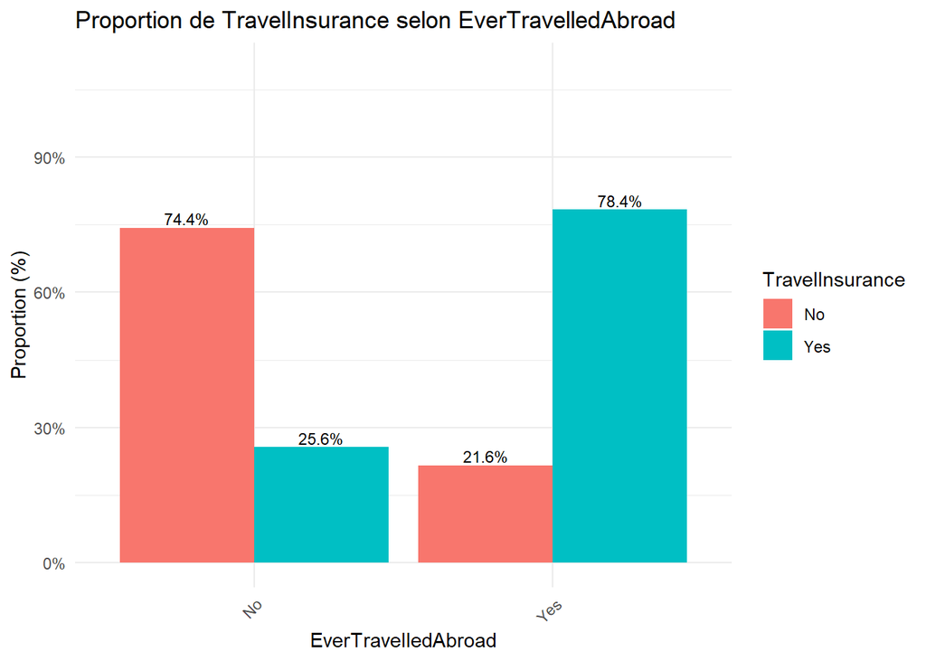

```r
categorical_vars <- setdiff(categorical_vars, "TravelInsurance")

for (var in categorical_vars) {
  print(barplot_croisement(base, var))
}
```

L’analyse des graphiques croisant la variable cible `TravelInsurance` avec plusieurs variables catégorielles met en évidence des **différences de comportement significatives** selon les profils :

**Synthese**

Les variables **`EverTravelledAbroad`**, **`FrequentFlyer`**, **`Employment Type`** et **`FamilyMembers`** se distinguent clairement par leur **pouvoir explicatif élevé**. Elles devraient être **retenues en priorité dans les modèles prédictifs** (arbre, random forest, bagging, boosting) pour améliorer la **précision de la prédiction de la souscription** à une assurance voyage.

Les variables comme **`ChronicDiseases`** et **`GraduateOrNot`** présentent des effets **plus faibles mais potentiellement utiles** en complément.

## 2.4 **Test de Khi2 entre variables catégorielles et la variable cible**

```r
# Test du Khi2 entre les variables categorielles et la target

test_chi2_results <- function(data, categorical_vars, target = "TravelInsurance") {
  # Vérifier si categorical_vars est vide
  if (length(categorical_vars) == 0) {
    warning("La liste des variables catégorielles est vide.")
    return(data.frame())
  }

  # Vérifier si target existe dans les données
  if (!(target %in% names(data))) {
    stop(paste("La variable cible", target, "n'existe pas dans les données."))
  }

  # Initialiser le dataframe results
  results <- data.frame(Variable = character(),
                        p_value = numeric(),
                        Association = character(),
                        stringsAsFactors = FALSE)

  # Compteur pour le suivi
  variables_traitees <- 0

  for (var in categorical_vars) {
    # Vérifier si la variable existe
    if (!(var %in% names(data))) {
      warning(paste("La variable", var, "n'existe pas dans les données et sera ignorée."))
      next
    }

    # Créer le tableau de contingence
    tbl <- table(data[[var]], data[[target]])

    # Vérification que le tableau de contingence est valide (dimensions > 1)
    if (all(dim(tbl) > 1)) {
      test <- chisq.test(tbl)
      p_value <- test$p.value
      association <- ifelse(p_value < 0.05, "Oui", "Non")

      results <- rbind(results, data.frame(
        Variable = var,
        p_value = round(p_value, 4),
        Association = association
      ))

      variables_traitees <- variables_traitees + 1
    } else {
      warning(paste("La variable", var, "ne permet pas de créer un tableau de contingence valide (au moins une dimension est 1)."))
    }
  }

  # Informer sur le nombre de variables traitées
  message(paste("Nombre de variables ayant passé le test :", variables_traitees, "sur", length(categorical_vars)))

  return(results)
}

resultats_chi2 <- test_chi2_results(base, categorical_vars = categorical_vars, target = "TravelInsurance")
```

```
## Nombre de variables ayant passé le test : 6 sur 6
```

```r
print(resultats_chi2)
```

```
##              Variable p_value Association
## 1     Employment Type  0.0000         Oui
## 2       GraduateOrNot  0.4365         Non
## 3       FamilyMembers  0.0001         Oui
## 4     ChronicDiseases  0.4481         Non
## 5       FrequentFlyer  0.0000         Oui
## 6 EverTravelledAbroad  0.0000         Oui
```

Les variables **statistiquement liées à la souscription** à une assurance voyage (c’est-à-dire ayant une p-value < 0.05 au test du Khi²) sont :

1. **Employment Type**
2. **FamilyMembers**
3. **FrequentFlyer**
4. **EverTravelledAbroad**

Ces 4 variables présentent une association significative avec la variable cible `TravelInsurance` et peuvent donc être retenues pour la modélisation prédictive.

## 2.5 **Test de Kruskal-Wallis entre variables continues et la variable cible**

```r
test_kruskal_table <- function(df, continuous_vars, target = "TravelInsurance") {

  results <- data.frame(
    Variable = character(),
    p_value = numeric(),
    Décision = character(),
    stringsAsFactors = FALSE
  )

  for (num_var in continuous_vars) {

    data_clean <- df[!is.na(df[[num_var]]) & !is.na(df[[target]]), c(num_var, target)]

    groupes <- split(data_clean[[num_var]], data_clean[[target]])

    # Vérification : au moins 2 groupes valides avec au moins 10 obs

    group_sizes <- sapply(groupes, length)

    if (length(groupes) < 2) {
      p_value <- NA
      decision <- "Moins de 2 groupes valides"

    } else if (any(group_sizes < 10)) {
      p_value <- NA
      decision <- "Échantillon trop petit"

    } else {
      test <- kruskal.test(data_clean[[num_var]] ~ data_clean[[target]])
      p_value <- test$p.value
      decision <- ifelse(p_value < 0.05, "Significatif", "Pas Significatif")
    }

    results <- rbind(results, data.frame(
      Variable = num_var,
      p_value = p_value,
      Decision = decision,
      stringsAsFactors = FALSE
    ))
  }

  return(results)
}

test_kruskal_table(base, continuous_vars, target = "TravelInsurance")
```

```
##       Variable      p_value     Decision
## 1          Age 3.067559e-02 Significatif
## 2 AnnualIncome 3.017909e-70 Significatif
```

**Interprétation**

Le **test de Kruskal-Wallis**, test non paramétrique, permet d’évaluer si la distribution d’une variable continue varie de manière significative selon les modalités d’une variable catégorielle. Dans notre cas, il permet de tester si certaines caractéristiques quantitatives diffèrent selon que les individus ont souscrit ou non à une assurance voyage (`TravelInsurance`, avec modalités “Yes” et “No”).

**Âge :**

- La p-value obtenue est d’environ **0.0307**, ce qui est inférieure au seuil de 5 %. On conclut donc à un **effet significatif**.
- Cela signifie que **la distribution de l’âge (notamment la médiane)** diffère de manière significative entre les deux groupes.
- Cette observation confirme nos analyses descriptives : **les clients plus âgées souscrivent plus fréquemment à une assurance voyage** que les plus jeunes.

**Revenu annuel (AnnualIncome) :**

- La p-value est extrêmement faible (**3.02e-70**), ce qui indique une **très forte significativité statistique**.
- Il existe donc une **différence marquée de revenu annuel** entre les souscripteurs et les non-souscripteurs.
- Ce résultat suggère que **le revenu est un déterminant majeur dans la décision de souscription** : les clients disposant d’un revenu plus élevé sont **nettement plus enclins à souscrire** une assurance voyage.

# 3 **Comparaison des méthodes d’arbres**

Dans cette section, nous mettons en œuvre les techniques de modélisation ensemblistes étudiées en cours, conformément aux orientations définies dans le cadre du projet.

## 3.1 **Regression Trees et Pruning**

### 3.1.1 **Construction de l’arbre**

1. **Nettoyage des données** : Le nom de la variable `Employment Type` a été standardisé en `Employment_Type` pour éviter les erreurs de traitement et assurer la cohérence des noms de colonnes.
2. **Séparation des données** : Le jeu de données a été divisé en deux parties : 80% pour entraîner les modèles, 20% pour les tester. Cela garantit une évaluation réaliste de la performance du modèle sur des données nouvelles.
3. **Formatage de la variable cible** : La variable `TravelInsurance` (souscription à l’assurance) a été convertie en **facteur** pour qu’elle soit bien interprétée comme une variable catégorielle dans les modèles de classification.
4. **Construction du modèle d’arbre de décision** : Un **arbre de décision** a été construit pour prédire la souscription à partir des caractéristiques du client. Des contraintes comme la profondeur maximale et la taille minimale des nœuds ont été fixées pour éviter le surapprentissage.

```r
# Partition de la base en Train et en  Test

set.seed(123)

col_index <- which(names(base) == "Employment Type")

names(base)[col_index] <- "Employment_Type"

in_training <- as.vector(createDataPartition(y = base$TravelInsurance, times = 1, p = 0.8, list = FALSE))

training_set <- base[in_training, ]

testing_set <- base[-in_training, ]
```

```r
training_set$TravelInsurance <- factor(training_set$TravelInsurance, levels = c("No", "Yes"))

testing_set$TravelInsurance <- factor(testing_set$TravelInsurance, levels = c("No", "Yes"))
```

```r
#----------------------------------------------------
# Construction du modèle complet
#----------------------------------------------------

# Arbre avec toutes les variables sans prunning

set.seed(123)

m1_rpart <- rpart(TravelInsurance ~ Age + AnnualIncome + Employment_Type +
                    GraduateOrNot + ChronicDiseases + FrequentFlyer + EverTravelledAbroad,
                  data = training_set,
                  method = "class",
                  control = rpart.control(cp = 0,
                                          xval = 10,
                                          maxdepth = 7,
                                          minbucket = 5))
```

```r
#----------------------------------------------------
# Analyse du paramètre de complexité (CP)
#----------------------------------------------------

# Afficher la table du paramètre de complexité

printcp(m1_rpart)
```

```
##
## Classification tree:
## rpart(formula = TravelInsurance ~ Age + AnnualIncome + Employment_Type +
##     GraduateOrNot + ChronicDiseases + FrequentFlyer + EverTravelledAbroad,
##     data = training_set, method = "class", control = rpart.control(cp = 0,
##         xval = 10, maxdepth = 7, minbucket = 5))
##
## Variables actually used in tree construction:
## [1] Age             AnnualIncome    ChronicDiseases FrequentFlyer
## [5] GraduateOrNot
##
## Root node error: 568/1590 = 0.35723
##
## n= 1590
##
##           CP nsplit rel error  xerror     xstd
## 1 0.39260563      0   1.00000 1.00000 0.033640
## 2 0.00704225      1   0.60739 0.60739 0.028937
## 3 0.00264085      3   0.59331 0.61268 0.029027
## 4 0.00176056     10   0.56866 0.64613 0.029580
## 5 0.00088028     11   0.56690 0.64085 0.029495
## 6 0.00000000     16   0.56162 0.65317 0.029692
```

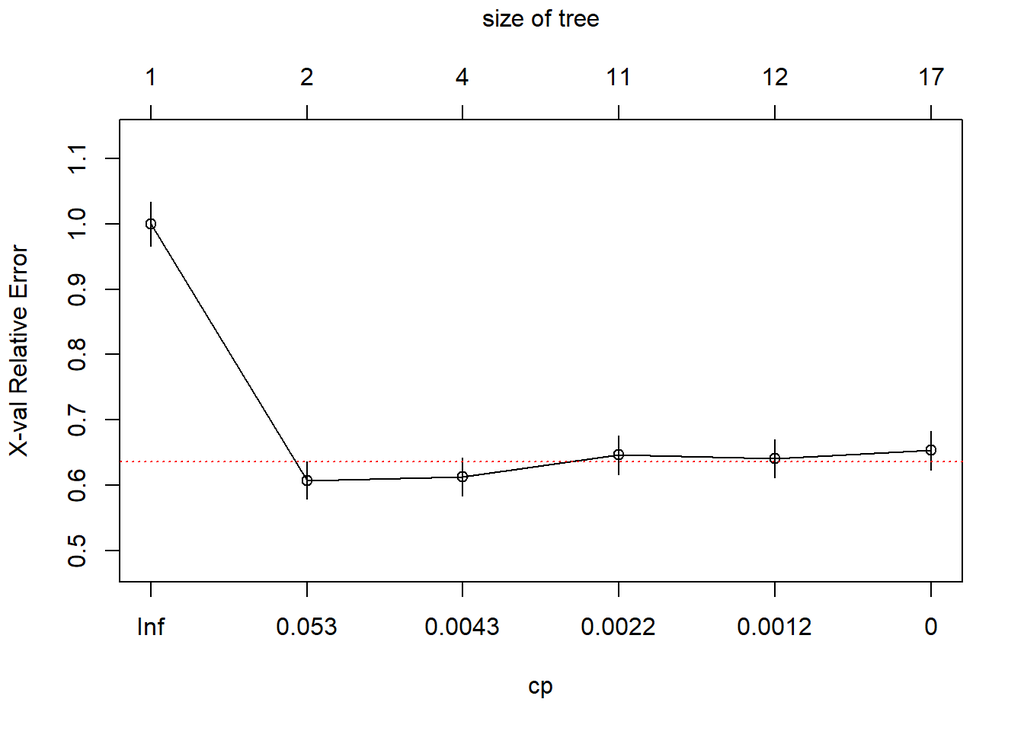

Variation des cps

Cependant, selon la règle du 1-SE (ligne rouge), on peut choisir un arbre plus petit (cp ≈ 0.053) avec seulement 2 feuilles, car son erreur est dans la marge d’erreur acceptable.

### 3.1.2 **Mise en place d’une procédure de pruning afin d’éviter le sur-apprentissage.**

Dans cette section,on identifie le paramètre de complexité (cp) minimisant l’erreur de validation croisée et trace la règle du 1SE pour sélectionner un arbre plus simple mais performant. Le graphique affiche l’évolution de l’erreur en fonction de log(CP), avec une ligne rouge marquant le seuil 1SE.

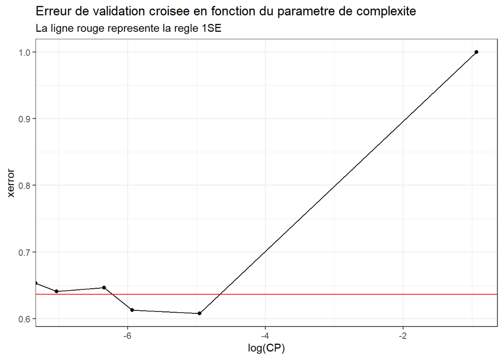

```r
SE <- m1_rpart$cptable[which.min(m1_rpart$cptable[, 4]), 5]
min_error <- m1_rpart$cptable[which.min(m1_rpart$cptable[, 4]), 4]
boundary <- min_error + SE

# Graphique de l'erreur de validation croisée et limite 1SE
ggplot() +
  geom_line(aes(x = log(m1_rpart$cptable[, 1]), y = m1_rpart$cptable[, 4])) +
  geom_point(aes(x = log(m1_rpart$cptable[, 1]), y = m1_rpart$cptable[, 4])) +
  geom_hline(aes(yintercept = boundary), color = "red") +
  scale_x_continuous(name = "log(CP)") +
  scale_y_continuous(name = "xerror") +
  theme_bw() +
  labs(title = "Erreur de validation croisee en fonction du parametre de complexite",
       subtitle = "La ligne rouge represente la regle 1SE")
```

```r
# Extraction du cp optimal selon le minimum d'erreur

cp_min <- m1_rpart$cptable[which.min(m1_rpart$cptable[, 4]), 1]

print(cp_min)
```

```
## [1] 0.007042254
```

```r
cp_star <- cp_min

# Grille autour de cp_star

grid <- expand.grid(cp = seq(cp_star / 2, cp_star * 2, length.out = 20))

# Contrôle de validation croisée pour classification

ctrl <- trainControl(
  method = "cv",
  number = 10,
  summaryFunction = defaultSummary,
  classProbs = TRUE,
  verboseIter = TRUE
)

# Modèle avec CV en minimisant l'erreur (1 - Accuracy)
set.seed(123)
cv_model <- train(
  TravelInsurance ~ Age + AnnualIncome + Employment_Type +
    GraduateOrNot + ChronicDiseases + FrequentFlyer + EverTravelledAbroad,
  data = training_set,
  method = "rpart",
  trControl = ctrl,
  tuneGrid = grid,
  metric = "Accuracy"
)
print(cv_model)
```

```
## CART
##
## 1590 samples
##    7 predictor
##    2 classes: 'No', 'Yes'
##
## No pre-processing
## Resampling: Cross-Validated (10 fold)
## Summary of sample sizes: 1430, 1432, 1431, 1432, 1431, 1431, ...
## Resampling results across tuning parameters:
##
##   cp           Accuracy   Kappa
##   0.003521127  0.7710814  0.4393576
##   0.004077094  0.7761288  0.4500426
##   0.004633062  0.7786446  0.4535401
##   0.005189029  0.7799104  0.4556366
##   0.005744996  0.7811604  0.4582773
##   0.006300964  0.7817893  0.4600644
##   0.006856931  0.7817893  0.4600644
##   0.007412898  0.7817893  0.4600644
##   0.007968866  0.7830472  0.4636546
##   0.008524833  0.7830472  0.4636546
##   0.009080801  0.7830472  0.4636546
##   0.009636768  0.7830472  0.4636546
##   0.010192735  0.7830472  0.4636546
##   0.010748703  0.7830472  0.4636546
##   0.011304670  0.7830472  0.4636546
##   0.011860638  0.7830472  0.4636546
##   0.012416605  0.7830472  0.4636546
##   0.012972572  0.7830472  0.4636546
##   0.013528540  0.7830472  0.4636546
##   0.014084507  0.7830472  0.4636546
##
## Accuracy was used to select the optimal model using the largest value.
## The final value used for the model was cp = 0.01408451.
```

```r
# Extraire le meilleur CP
best_cp <- cv_model$bestTune$cp
cat("Meilleur CP (minimisant l'erreur de validation croisee):", best_cp, "\n")
```

```
## Meilleur CP (minimisant l'erreur de validation croisee): 0.01408451
```

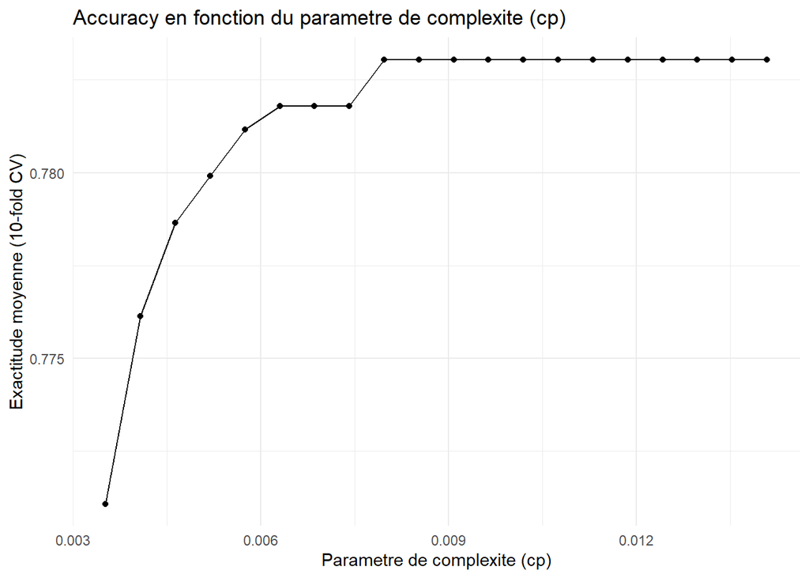

```r
# Tracer Accuracy vs CP
ggplot(cv_model$results, aes(x = cp, y = Accuracy)) +
  geom_line() +
  geom_point() +
  theme_minimal() +
  labs(
    title = "Accuracy en fonction du parametre de complexite (cp)",
    x = "Parametre de complexite (cp)",
    y = "Exactitude moyenne (10-fold CV)"
  )
```

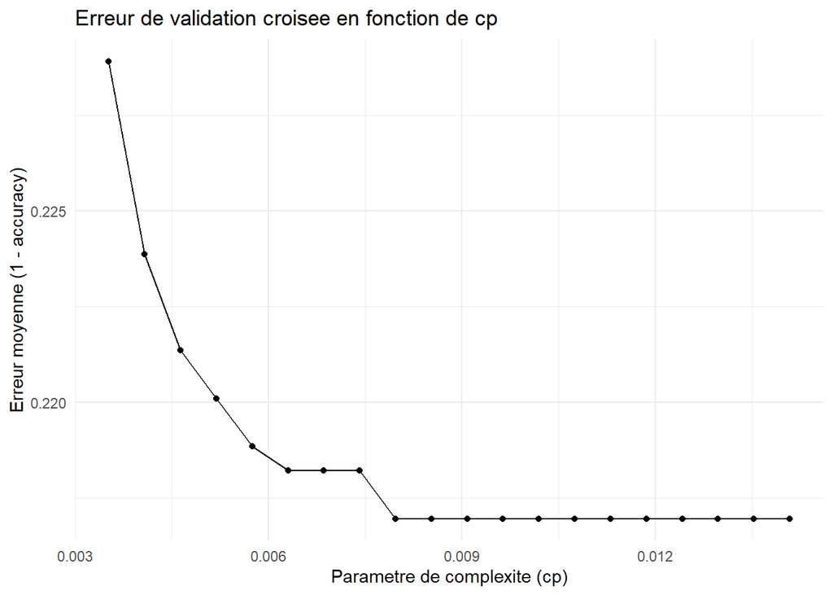

```r
ggplot(cv_model$results, aes(x = cp, y = 1 - Accuracy)) +
  geom_line() +
  geom_point() +
  theme_minimal() +
  labs(
    title = "Erreur de validation croisee en fonction de cp",
    x = "Parametre de complexite (cp)",
    y = "Erreur moyenne (1 - accuracy)"
  )
```

### 3.1.3 **Construction de l’arbre optimal**

```r
# Construction de l'arbre optimal avec le CP trouvé

arbre_optimal <- rpart(
  TravelInsurance ~ Age + AnnualIncome + Employment_Type +
    GraduateOrNot + ChronicDiseases + FrequentFlyer + EverTravelledAbroad,
  data = training_set,
  method = "class",
  control = rpart.control(cp = best_cp)
)
```

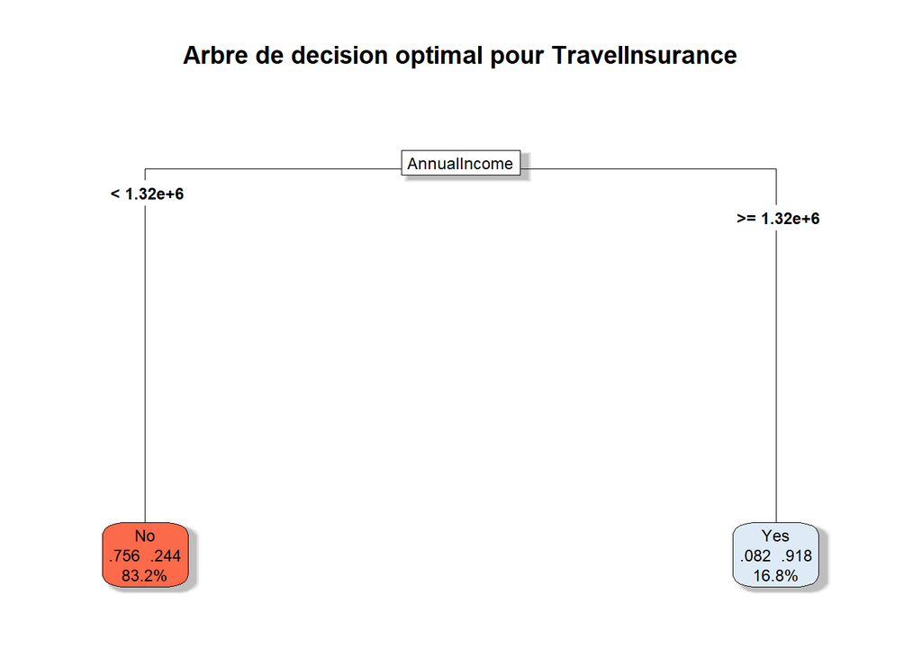

```r
rpart.plot(arbre_optimal,
           type = 5,
           extra = 104,  # Afficher les pourcentages et nombres
           box.palette = "RdBu",
           fallen.leaves = TRUE,
           under = FALSE,
           digits = 3,
           cex = 0.75,
           shadow.col = "gray",
           main = "Arbre de decision optimal pour TravelInsurance")
```

**Interprétation de l’arbre de décision optimal**

L’arbre de décision optimal obtenu (avec le meilleur paramètre de complexité `cp`) repose uniquement sur la variable **AnnualIncome** pour prédire la souscription à une assurance voyage.

La variable `AnnualIncome` s’impose comme le meilleur discriminant pour prédire la souscription. Elle suffit à elle seule à séparer efficacement les clients en deux groupes distincts, révélant un effet fort du revenu sur la décision de souscription.

### 3.1.4 **Importance des variables issues de l’arbre optimal.**

Ici, nous allons présentons les graphiques donnant l’importance des variables du modele d’arbre de décision.

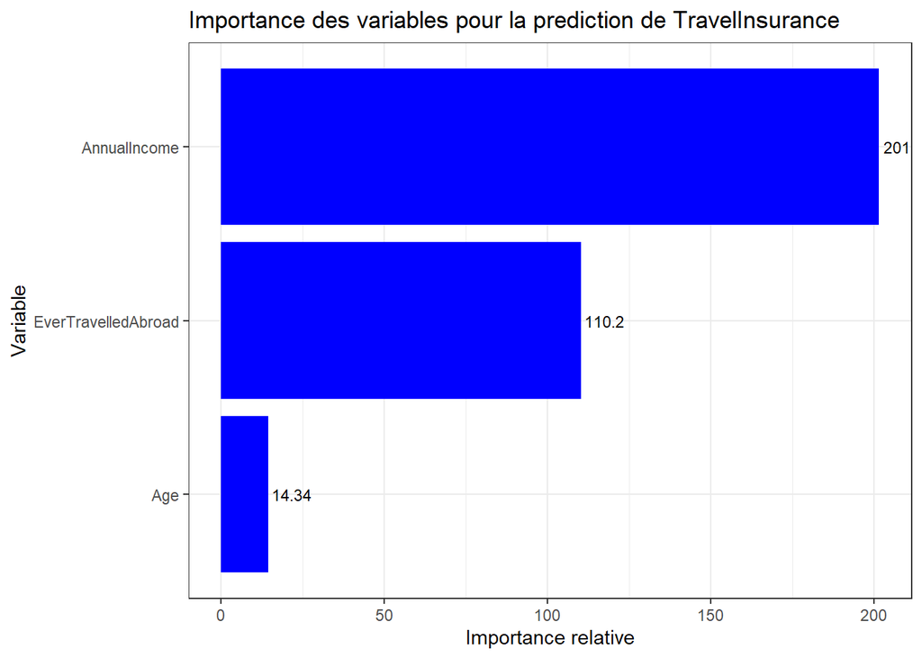

```r
# Création d'un data frame avec l'importance des variables
var_importance <- data.frame(
  Variable = names(arbre_optimal$variable.importance),
  Importance = arbre_optimal$variable.importance
)

ggplot(var_importance, aes(x = reorder(Variable, Importance), y = Importance)) +
  geom_bar(stat = 'identity', fill = "blue") +
  geom_text(aes(label = round(Importance, 2)), hjust = -0.1, size = 3) +
  coord_flip() +
  labs(
    title = "Importance des variables pour la prediction de TravelInsurance",
    x = "Variable",
    y = "Importance relative"
  ) +
  theme_bw()
```

Ce graphique montre l’**importance relative des variables** dans l’arbre de décision construit pour prédire la souscription à une assurance voyage (`TravelInsurance`).

**AnnualIncome** est de loin la variable la plus influente, avec une importance relative de **201**, ce qui signifie qu’elle est fortement utilisée dans les critères de séparation de l’arbre. Elle constitue **le facteur principal de décision** dans la classification.

**Age**, avec une importance beaucoup plus faible (**14.34**), a un effet marginal dans l’arbre actuel. Elle peut intervenir dans quelques feuilles profondes mais **n’est pas discriminante au niveau global**.

**Conclusion :** L’algorithme a principalement retenu **le revenu annuel** et **l’expérience de voyage à l’étranger** comme indicateurs majeurs pour prédire la souscription. Cela **confirme et complète visuellement** les résultats issus des statistiques descriptives et du test de Khi2.

### 3.1.5 **Graphique de dépendance des variables importantes.**

#### 3.1.5.1 **Cas des variables continues de forte importance**

Dans cette section, nous allons afficher les graphiques montrant les dépendances des variables importantes.

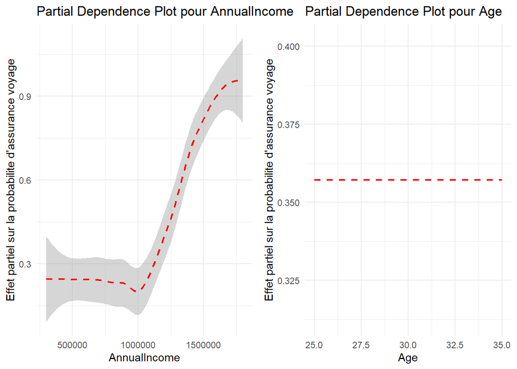

Graphique de dépendance

**Interprétation des Partial Dependence Plots (PDP)**

- **AnnualIncome**

Le PDP montre que la probabilité de souscrire à une assurance voyage augmente fortement avec le **revenu annuel**.

**Conclusion** : Le revenu annuel est un **facteur déterminant** dans la décision de souscription à une assurance voyage.

- **Age**

Le PDP de l’âge montre une **courbe plate**, indiquant que :

- La **probabilité de souscription** reste **stable** quel que soit l’âge des individus dans l’échantillon.
- Il n’y a **aucune variation notable** de l’effet de l’âge sur la prédiction du modèle.

**Conclusion** : Une fois la variable revenu intégrée dans le modèle d’arbre, l’âge n’apporte plus d’information prédictive significative supplémentaire concernant la souscription à l’assurance.

#### 3.1.5.2 **Cas des variables catégorielles de forte importance**

```r
# PDP pour les variables catégorielles

pdp_categorical <- function(model, var_name, data) {
  # Obtenir les niveaux uniques de la variable
  values <- sort(unique(data[[var_name]]))

  # Créer un data frame pour stocker les résultats
  pdp_result <- data.frame(
    variable = values,
    effect = numeric(length(values))
  )
  names(pdp_result)[1] <- var_name

  # Pour chaque valeur, calculer l'effet moyen
  for (i in seq_along(values)) {
    # Créer une copie des données où la variable est fixée à la valeur actuelle
    temp_data <- data
    temp_data[[var_name]] <- values[i]

    # Prédire et calculer la moyenne des probabilités pour la classe positive
    pred <- predict(model, temp_data, type = "prob")[, 2]
    pdp_result$effect[i] <- mean(pred, na.rm = TRUE)
  }

  return(pdp_result)
}

# Identifier quelles variables catégorielles sont parmi les plus importantes
cat_top_vars <- intersect(top_vars, categorical_vars)
cat("Variables catégorielles importantes:", paste(cat_top_vars, collapse=", "), "\n")
```

```
## Variables catégorielles importantes: EverTravelledAbroad
```

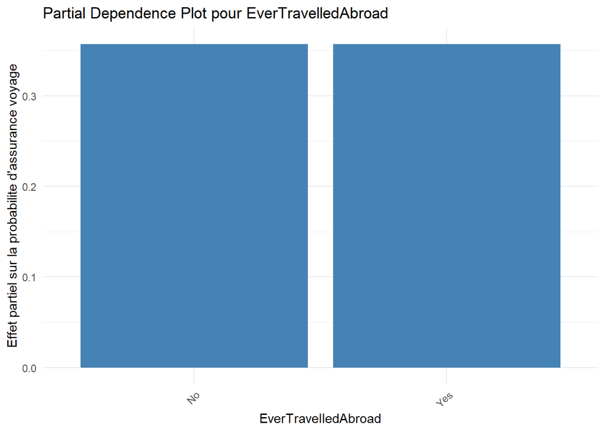

```r
# Créer un graphique pour chaque variable catégorielle importante
cat_pdp_plots <- list()
if (length(cat_top_vars) > 0) {
  for (i in 1:length(cat_top_vars)) {
    var <- cat_top_vars[i]
    # Générer les données du PDP
    pdp_data <- pdp_categorical(arbre_optimal, var, training_set)

    # Créer le graphique
    p <- ggplot(pdp_data, aes_string(x = var, y = "effect")) +
      geom_bar(stat = "identity", fill = "steelblue") +
      theme_minimal() +
      theme(axis.text.x = element_text(angle = 45, hjust = 1)) +
      labs(title = paste("Partial Dependence Plot pour", var),
           y = "Effet partiel sur la probabilite d'assurance voyage",
           x = var)

    # Stocker le graphique
    cat_pdp_plots[[i]] <- p
  }

  # Afficher tous les graphiques
  if (requireNamespace("gridExtra", quietly = TRUE)) {
    gridExtra::grid.arrange(
      grobs = cat_pdp_plots,
      ncol = min(2, length(cat_top_vars))
    )
  } else {
    # Si gridExtra n'est pas disponible, afficher les graphiques un par un
    for (p in cat_pdp_plots) {
      print(p)
    }
  }
} else {
  cat("Aucune variable catégorielle trouvée parmi les plus importantes.\n")
}
```

```r
# Version ultra-simplifiée pour afficher les PDP des variables catégorielles
cat_top_vars <- intersect(top_vars, categorical_vars)
cat("Variables catégorielles importantes:", paste(cat_top_vars, collapse=", "), "\n")
```

```
## Variables catégorielles importantes: EverTravelledAbroad
```

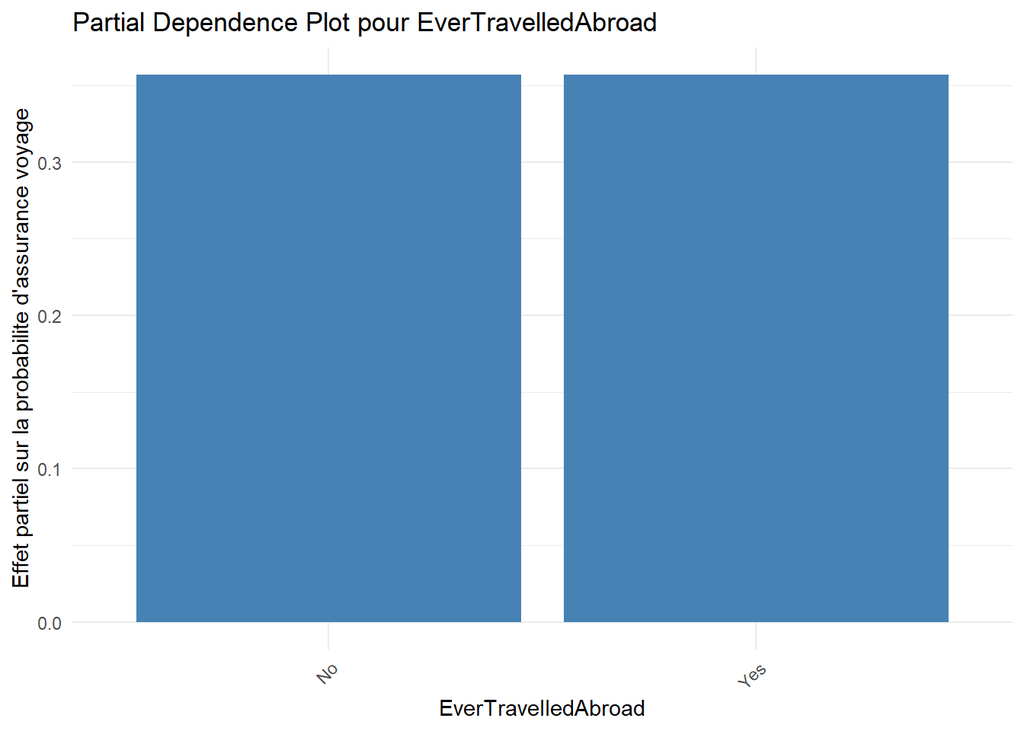

```r
for (var in cat_top_vars) {
  # Générer les données du PDP
  pdp_data <- pdp_categorical(arbre_optimal, var, training_set)

  # Créer et afficher le graphique directement
  p <- ggplot(pdp_data, aes_string(x = var, y = "effect")) +
    geom_bar(stat = "identity", fill = "steelblue") +
    theme_minimal() +
    theme(axis.text.x = element_text(angle = 45, hjust = 1)) +
    labs(title = paste("Partial Dependence Plot pour", var),
         y = "Effet partiel sur la probabilite d'assurance voyage",
         x = var)

  print(p)
}
```

Ce graphique représente un **diagramme de dépendance partielle (Partial Dependence Plot, PDP)** pour la variable **catégorielle `EverTravelledAbroad`**, qui indique si un individu a déjà voyagé à l’étranger ou non.

Les deux barres sont **presque identiques**, ce qui signifie que la variable `EverTravelledAbroad` **n’a pas un impact significatif** sur la prédiction du modèle.

Que la personne ait **déjà voyagé à l’étranger** ou non **n’influence presque pas** la probabilité prédite de souscrire à une assurance voyage, **selon le modèle**.

### 3.1.6 **Evaluation du modele d’arbre sur les données test**

```r
# Prédictions
pred_train <- predict(arbre_optimal, training_set, type = "class")
pred_test <- predict(arbre_optimal, testing_set, type = "class")

# Probabilités pour courbe ROC
pred_train_prob <- predict(arbre_optimal, training_set, type = "prob")[, 2]
pred_test_prob <- predict(arbre_optimal, testing_set, type = "prob")[, 2]

# Courbes ROC
roc_train <- roc(training_set$TravelInsurance, pred_train_prob)
roc_test <- roc(testing_set$TravelInsurance, pred_test_prob)
```

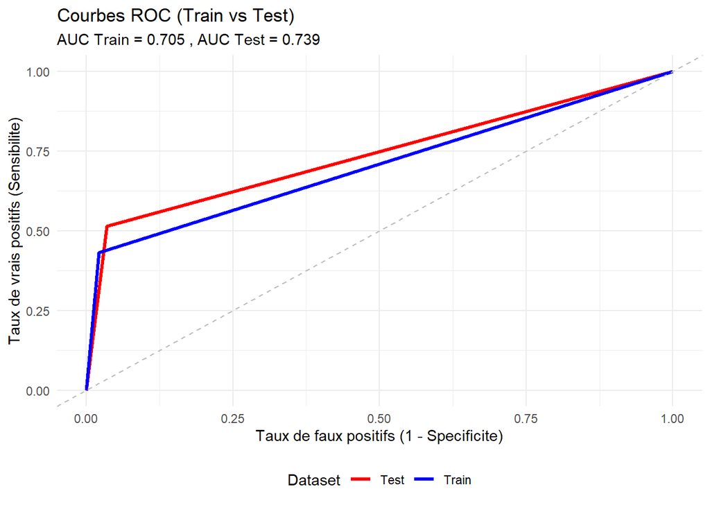

```r
roc_train_df <- data.frame(
  Specificity = 1 - roc_train$specificities,
  Sensitivity = roc_train$sensitivities,
  Dataset = "Train"
)

roc_test_df <- data.frame(
  Specificity = 1 - roc_test$specificities,
  Sensitivity = roc_test$sensitivities,
  Dataset = "Test"
)

roc_df <- rbind(roc_train_df, roc_test_df)

ggplot(roc_df, aes(x = Specificity, y = Sensitivity, color = Dataset)) +
  geom_line(size = 1.2) +
  geom_abline(intercept = 0, slope = 1, linetype = "dashed", color = "gray") +
  scale_color_manual(values = c("Train" = "blue", "Test" = "red")) +
  theme_minimal() +
  labs(title = "Courbes ROC (Train vs Test)",
       subtitle = paste("AUC Train =", round(auc(roc_train), 3),
                        ", AUC Test =", round(auc(roc_test), 3)),
       x = "Taux de faux positifs (1 - Specificite)",
       y = "Taux de vrais positifs (Sensibilite)") +
  theme(legend.position = "bottom")
```

## 3.2 **Méthodes d’Ensemble : Bagging**

### 3.2.1 **Mise en œuvre du bagging avec des arbres de décision**

Dans notre étude, nous avons mis en œuvre la méthode de bagging (Bootstrap Aggregating) en combinant plusieurs **arbres de décision** construits sur des échantillons bootstrap. Cette technique vise à **réduire la variance** d’un modèle unique et à obtenir des prédictions plus stables.

Pour cela, nous avons généré **50 sous-échantillons bootstrap** à partir des données d’apprentissage. Sur chacun de ces échantillons, un arbre de décision a été entraîné selon une formule de classification utilisant les variables explicatives disponibles.

Chaque arbre a été construit avec un **paramètre de complexité $cp$ optimisé** (issu de la méthode d’arbre) afin d’éviter les arbres trop complexes ou trop simples. L’ensemble des modèles est ensuite utilisé pour prédire via **vote majoritaire** (ou moyenne de probabilité dans une version probabiliste).

Ce procédé permet de renforcer la **généralisation du modèle**, en lissant les erreurs spécifiques à un échantillon particulier.

```r
set.seed(123)

bootstrap_samples <- createResample(training_set$TravelInsurance, times = 50)

bagg_cart <- lapply(bootstrap_samples, function(X) {
  rpart(TravelInsurance ~ Age + AnnualIncome + Employment_Type +
          GraduateOrNot + ChronicDiseases + FrequentFlyer + EverTravelledAbroad,
        data = training_set[X, ],
        method = "class",
        control = rpart.control(cp = best_cp,
                                xval = 5))
})
```

Pour évaluer comment la performance et la variance évoluent en fonction du nombre d’arbres, nous allons créer des modèles avec différents nombres d’arbres et mesurer leurs performances.

```r
# Vérifier s'il y a des conflits de noms avec des fonctions R

problematic_names <- c()
for (col_name in colnames(training_set)) {
  if (exists(col_name, mode = "function")) {
    problematic_names <- c(problematic_names, col_name)
  }
}

if (length(problematic_names) > 0) {
  cat("\nATTENTION: Colonnes avec des noms conflictuels:\n")
  print(problematic_names)
}

# ===============================================
# SOLUTION ROBUSTE AVEC ISOLATION DES VARIABLES
# ===============================================


# Fonction pour nettoyer les noms de colonnes

clean_column_names <- function(df) {
  # Supprimer les espaces et caractères spéciaux
  clean_names <- make.names(colnames(df), unique = TRUE)
  colnames(df) <- clean_names
  return(df)
}

# Nettoyer les datasets

training_set_clean <- clean_column_names(training_set)
testing_set_clean <- clean_column_names(testing_set)


# Paramètres
ntrees_values <- c(1, 2,3,5,8,10, 12,15, 20,25, 30,35, 40, 50,60, 75,80,90, 100, 150, 200, 250, 300)
n_samples <- 100
set.seed(123)

# Initialisation des résultats
performance_results <- data.frame(
  ntrees = ntrees_values,
  accuracy = numeric(length(ntrees_values)),
  auc = numeric(length(ntrees_values)),
  variance = numeric(length(ntrees_values))
)

# Stockage des prédictions avec isolation de l'environnement
all_tree_preds <- vector("list", n_samples)
successful_trees <- 0

cat("\n=== CONSTRUCTION DES ARBRES ===\n")
```

```
##
## === CONSTRUCTION DES ARBRES ===
```

```r
# Création d'un environnement isolé pour éviter les conflits

isolated_env <- new.env()

# Fonction personnalisée pour calculer la variance sans conflit

safe_variance <- function(x) {
  if (length(x) <= 1) return(0)
  n <- length(x)
  mean_x <- sum(x) / n
  sum((x - mean_x)^2) / (n - 1)
}

for (i in 1:n_samples) {
  tryCatch({
    # Bootstrap avec environnement isolé
    boot_indices <- sample(nrow(training_set_clean), replace = TRUE)
    train_boot <- training_set_clean[boot_indices, ]

    # Vérifier la diversité des classes
    class_counts <- table(train_boot$TravelInsurance)
    if (length(class_counts) < 2 || min(class_counts) < 3) {
      next
    }

    predictor_vars <- setdiff(colnames(train_boot), "TravelInsurance")
    formula_string <- paste("TravelInsurance ~", paste(predictor_vars, collapse = " + "))
    tree_formula <- as.formula(formula_string)

    # Utiliser l'environnement isolé pour la construction
    tree_model <- eval(
      expr = rpart(
        formula = tree_formula,
        data = train_boot,
        method = "class",
        control = rpart.control(
          cp = 0.01,
          minsplit = 10,
          minbucket = 3,
          maxdepth = 10,
          xval = 0
        )
      ),
      envir = isolated_env
    )

    # Vérifier que l'arbre est valide
    if (!is.null(tree_model) && length(unique(predict(tree_model, train_boot, type = "class"))) > 1) {

      # Prédictions avec gestion robuste
      pred_result <- predict(tree_model, testing_set_clean, type = "prob")

      if (is.matrix(pred_result) && ncol(pred_result) >= 2) {
        # Déterminer la colonne de la classe positive
        target_levels <- levels(testing_set_clean$TravelInsurance)
        positive_class <- target_levels[length(target_levels)]

        if (positive_class %in% colnames(pred_result)) {
          prob_positive <- pred_result[, positive_class]
        } else {
          prob_positive <- pred_result[, ncol(pred_result)]  # Dernière colonne
        }

        # Vérifier que les probabilités sont valides
        if (all(is.finite(prob_positive)) && all(prob_positive >= 0 & prob_positive <= 1)) {
          all_tree_preds[[i]] <- prob_positive
          successful_trees <- successful_trees + 1
        }
      }
    }

  }, error = function(e) {
    cat("Erreur à l'arbre", i, ":", e$message, "\n")
  })

  # Affichage du progrès
  if (i %% 25 == 0) {
    cat("Progres:", i, "/", n_samples, "- Arbres réussis:", successful_trees, "\n")
  }
}
```

```
## Progres: 25 / 100 - Arbres réussis: 25
## Progres: 50 / 100 - Arbres réussis: 50
## Progres: 75 / 100 - Arbres réussis: 75
## Progres: 100 / 100 - Arbres réussis: 100
```

```r
cat("Arbres construits avec succes:", successful_trees, "/", n_samples, "\n")
```

```
## Arbres construits avec succes: 100 / 100
```

```r
# Filtrer et convertir les prédictions
valid_preds <- all_tree_preds[!sapply(all_tree_preds, is.null)]

if (length(valid_preds) == 0) {
  stop("Aucun arbre n'a pu être construit. Probleme avec les donnees.")
}

# Conversion en matrice avec gestion d'erreur
pred_matrix <- tryCatch({
  do.call(cbind, valid_preds)
}, error = function(e) {
  cat("Erreur lors de la conversion en matrice:", e$message, "\n")
  return(NULL)
})

if (is.null(pred_matrix)) {
  stop("Impossible de creer la matrice de predictions")
}

cat("Matrice créée:", nrow(pred_matrix), "x", ncol(pred_matrix), "\n")
```

```
## Matrice créée: 397 x 100
```

```r
# ===============================================
# ÉVALUATION AVEC FONCTIONS SÛRES
# ===============================================

cat("\n=== EVALUATION DES PERFORMANCES ===\n")
```

```
##
## === EVALUATION DES PERFORMANCES ===
```

```r
for (i in seq_along(ntrees_values)) {
  ntrees_current <- min(ntrees_values[i], ncol(pred_matrix))

  if (ntrees_current > 0) {
    tryCatch({
      # Calcul des prédictions moyennes
      if (ntrees_current == 1) {
        ensemble_probs <- pred_matrix[, 1]
      } else {
        ensemble_probs <- rowMeans(pred_matrix[, 1:ntrees_current, drop = FALSE])
      }

      # Classification
      target_levels <- levels(testing_set_clean$TravelInsurance)
      positive_class <- target_levels[length(target_levels)]
      negative_class <- target_levels[1]

      ensemble_classes <- factor(
        ifelse(ensemble_probs > 0.5, positive_class, negative_class),
        levels = target_levels
      )

      # Calcul de l'accuracy avec gestion d'erreur
      performance_results$accuracy[i] <- mean(ensemble_classes == testing_set_clean$TravelInsurance, na.rm = TRUE)

      # Calcul de l'AUC avec gestion d'erreur
      tryCatch({
        roc_obj <- roc(testing_set_clean$TravelInsurance, ensemble_probs, quiet = TRUE)
        performance_results$auc[i] <- as.numeric(auc(roc_obj))
      }, error = function(e) {
        performance_results$auc[i] <<- NA
      })

      # Calcul de la variance avec fonction sûre
      if (ntrees_current > 1) {
        variances <- numeric(nrow(pred_matrix))
        for (j in 1:nrow(pred_matrix)) {
          variances[j] <- safe_variance(pred_matrix[j, 1:ntrees_current])
        }
        performance_results$variance[i] <- mean(variances, na.rm = TRUE)
      }

    }, error = function(e) {
      cat("Erreur pour ntrees =", ntrees_values[i], ":", e$message, "\n")
    })
  }
}

# Nettoyage des résultats
performance_results <- performance_results[!is.na(performance_results$accuracy), ]

# Affichage des résultats
cat("\n=== RESULTATS FINAUX ===\n")
```

```
##
## === RESULTATS FINAUX ===
```

```r
print(performance_results)
```

```
##    ntrees accuracy       auc     variance
## 1       1 0.836272 0.7882767 0.0000000000
## 2       2 0.836272 0.7890638 0.0014264043
## 3       3 0.836272 0.7890638 0.0009879668
## 4       5 0.836272 0.7890638 0.0006943728
## 5       8 0.836272 0.7917288 0.0012302302
## 6      10 0.836272 0.7917288 0.0011560620
## 7      12 0.836272 0.7917288 0.0010846661
## 8      15 0.836272 0.7917288 0.0014873252
## 9      20 0.836272 0.7950842 0.0014387179
## 10     25 0.836272 0.7950842 0.0014598252
## 11     30 0.836272 0.7950842 0.0013458575
## 12     35 0.836272 0.7955261 0.0014243990
## 13     40 0.836272 0.7955261 0.0014096268
## 14     50 0.836272 0.7955261 0.0013928843
## 15     60 0.836272 0.7953604 0.0015304563
## 16     75 0.836272 0.7953604 0.0016045765
## 17     80 0.836272 0.7953604 0.0016251170
## 18     90 0.836272 0.7953880 0.0015898556
## 19    100 0.836272 0.7971555 0.0015976615
## 20    150 0.836272 0.7971555 0.0015976615
## 21    200 0.836272 0.7971555 0.0015976615
## 22    250 0.836272 0.7971555 0.0015976615
## 23    300 0.836272 0.7971555 0.0015976615
```

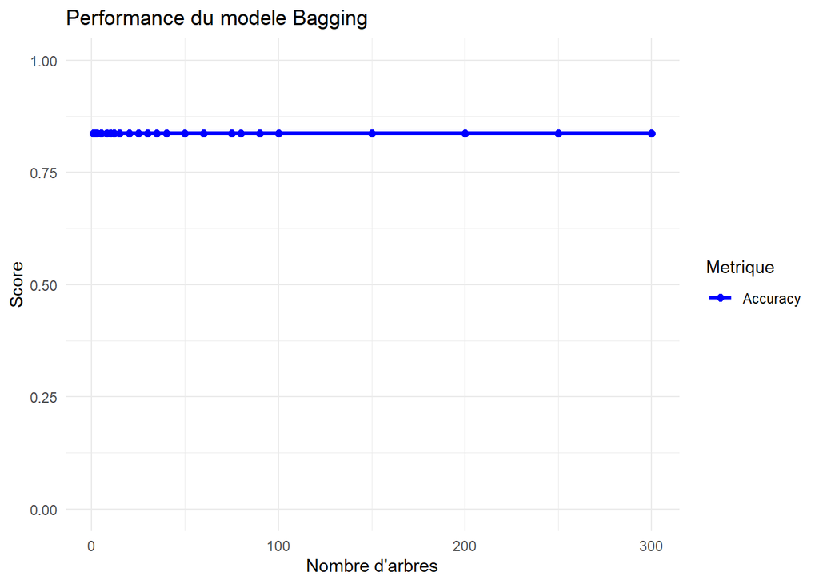

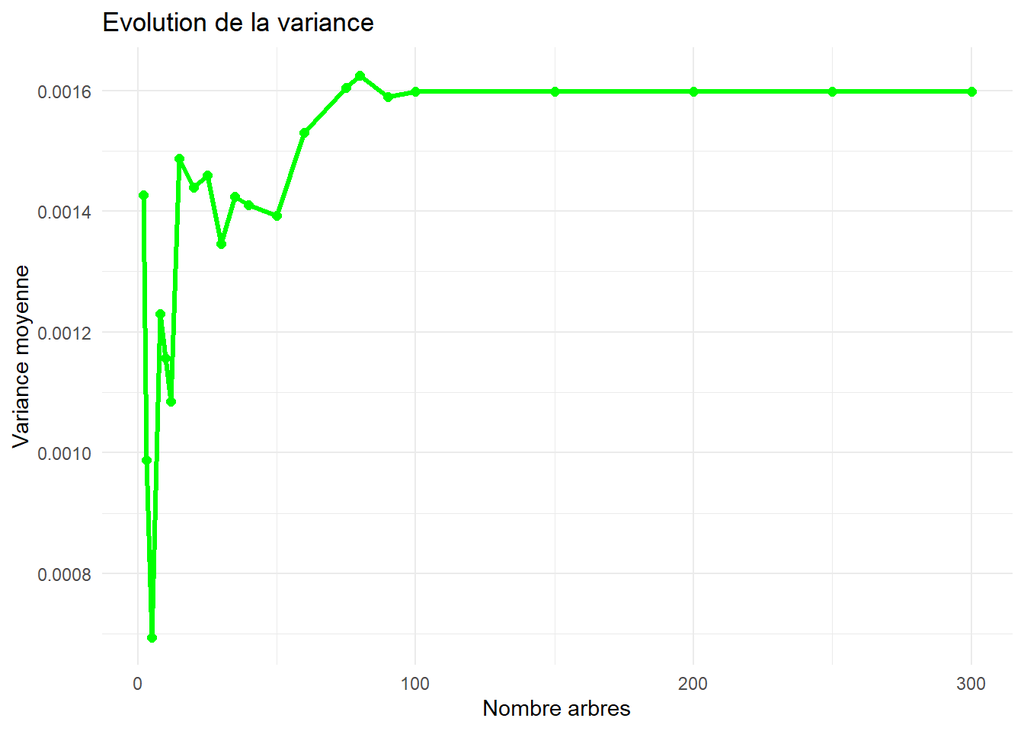

```r
# Graphiques avec gestion d'erreur

if (nrow(performance_results) > 0) {
  tryCatch({
    # Graphique principal
    p1 <- ggplot(performance_results, aes(x = ntrees)) +
      geom_line(aes(y = accuracy, color = "Accuracy"), size = 1.2) +
      geom_point(aes(y = accuracy, color = "Accuracy"), size = 2) +
      scale_color_manual(values = c("Accuracy" = "blue")) +
      labs(title = "Performance du modele Bagging",
           x = "Nombre d'arbres",
           y = "Score",
           color = "Metrique") +
      theme_minimal() +
      ylim(0, 1)

    print(p1)

    # Graphique de variance si données disponibles

    variance_data <- performance_results[!is.na(performance_results$variance) & performance_results$variance > 0, ]
    if (nrow(variance_data) > 0) {
      p2 <- ggplot(variance_data, aes(x = ntrees, y = variance)) +
        geom_line(color = "green", size = 1.2) +
        geom_point(color = "green", size = 2) +
        labs(title = "Evolution de la variance",
             x = "Nombre arbres",
             y = "Variance moyenne") +
        theme_minimal()

      print(p2)
    }

  }, error = function(e) {
    cat("Erreur lors de la création des graphiques:", e$message, "\n")
  })
}
```

**Stabilité de l’accuracy**

Comme le montre le tableau et le graphique “Performance du modèle Bagging”, **l’exactitude (accuracy)** du modèle reste constante à **0.836** dès le premier arbre jusqu’à 300 arbres.

### 3.2.3 **Graphique des variables importances (Bagging)**

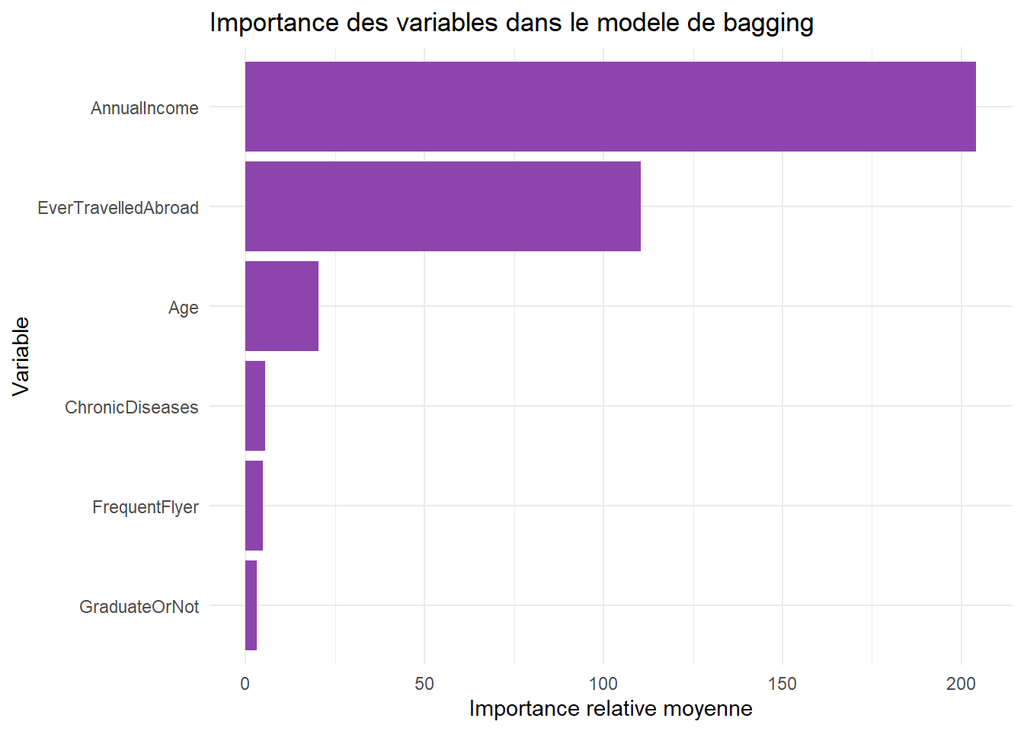

```r
var_importance_list <- lapply(bagg_cart, function(tree) {
  if (!is.null(tree$variable.importance)) {
    importance_df <- data.frame(
      variable = names(tree$variable.importance),
      importance = tree$variable.importance
    )
    return(importance_df)
  } else {
    return(NULL)
  }
})

var_importance_list <- var_importance_list[!sapply(var_importance_list, is.null)]

var_importance_combined <- do.call(rbind, var_importance_list)

var_importance_avg <- aggregate(importance ~ variable, data = var_importance_combined, FUN = mean)

var_importance_avg <- var_importance_avg[order(-var_importance_avg$importance), ]

# Créer le graphique d'importance des variables

ggplot(var_importance_avg, aes(x = reorder(variable, importance), y = importance)) +
  geom_bar(stat = "identity", fill = "#8E44AD") +
  coord_flip() +
  labs(title = "Importance des variables dans le modele de bagging",
       x = "Variable",
       y = "Importance relative moyenne") +
  theme_minimal()
```

Le graphique montre que, comme dans l’arbre de décision, les variables **AnnualIncome** et **EverTravelledAbroad** sont les plus influentes dans le modèle de bagging, suivies de **Age**. Les autres variables ont un impact négligeable sur la prédiction.

### 3.2.4 **Graphique de dépendance des variables : Variables continue (Bagging)**

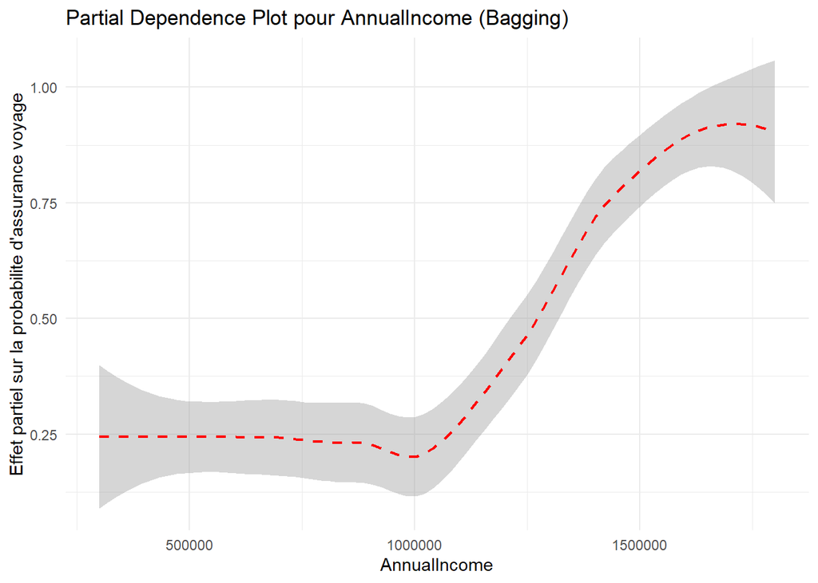

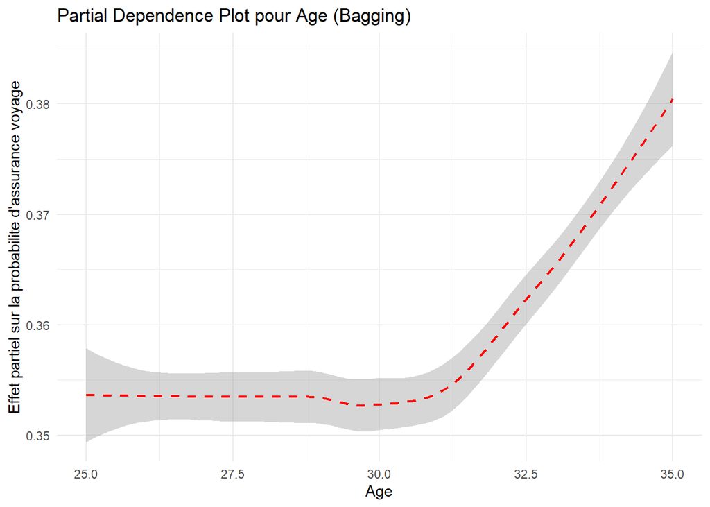

```r
# Fonction simplifiée pour PDP bagging


# 2. Partial Dependence Plots

# Fonction pour calculer le PDP pour une variable continue


pdp_bagging_continuous <- function(models, var_name, data, grid_size = 30) {
  # Déterminer la plage de valeurs à échantillonner
  var_min <- min(data[[var_name]], na.rm = TRUE)
  var_max <- max(data[[var_name]], na.rm = TRUE)
  grid_points <- seq(var_min, var_max, length.out = grid_size)

  # Créer le dataframe pour stocker les résultats
  pdp_result <- data.frame(
    x = grid_points,
    y = numeric(length(grid_points))
  )
  names(pdp_result)[1] <- var_name

  # Pour chaque point de la grille
  for (i in seq_along(grid_points)) {
    # Créer une copie des données avec la variable fixée
    temp_data <- data
    temp_data[[var_name]] <- grid_points[i]

    # Prédire avec chaque modèle
    predictions <- lapply(models, function(model) {
      predict(model, temp_data, type = "prob")[, 2]
    })

    # Moyenner les prédictions de tous les modèles
    avg_pred <- rowMeans(do.call(cbind, predictions))

    # Stocker le résultat
    pdp_result$y[i] <- mean(avg_pred)
  }

  return(pdp_result)
}

# Identifier les variables les plus importantes (top 2)
top_vars <- head(var_importance_avg$variable, 2)

# Identifier les variables continues
continuous_vars_bagging <- c("Age", "AnnualIncome")

# Créer les PDP pour les variables continues importantes

# Identifier les variables les plus importantes (top 3)
top_vars <- head(var_importance_avg$variable, 3)

# Identifier les variables continues et catégorielles
continuous_vars <- c("Age", "AnnualIncome")
categorical_vars <- c("Employment_Type", "GraduateOrNot", "ChronicDiseases", "FrequentFlyer", "EverTravelledAbroad")

# Créer les PDP pour les variables continues importantes
for (var in intersect(top_vars, continuous_vars)) {
  pdp_data <- pdp_bagging_continuous(bagg_cart, var, training_set)

  p <- ggplot(pdp_data, aes_string(x = var, y = "y"))+
    geom_smooth(method = "loess", se = TRUE, color = "red", linetype = "dashed", size = 0.8) +
    theme_minimal() +
    labs(title = paste("Partial Dependence Plot pour", var, "(Bagging)"),
         y = "Effet partiel sur la probabilite d'assurance voyage",
         x = var)

  print(p)
}
```

Les courbes de dépendance partielle (PDP) issues du modèle de Bagging confirment le rôle prédictif prépondérant du revenu annuel, avec un effet croissant et net sur la probabilité de souscription. Ce résultat est cohérent avec les observations issues de l’arbre de décision simple.

Contrairement à ce dernier, le modèle Bagging met davantage en évidence l’effet de l’âge : bien que son impact reste modéré, on observe une tendance légèrement croissante à partir de 30 ans. Cette dynamique est mieux capturée grâce à la stabilité accrue apportée par l’agrégation d’arbres dans la méthode de Bagging.

### 3.2.5 **Graphique de dépendance des variables : Variables catégorielles (Bagging)**

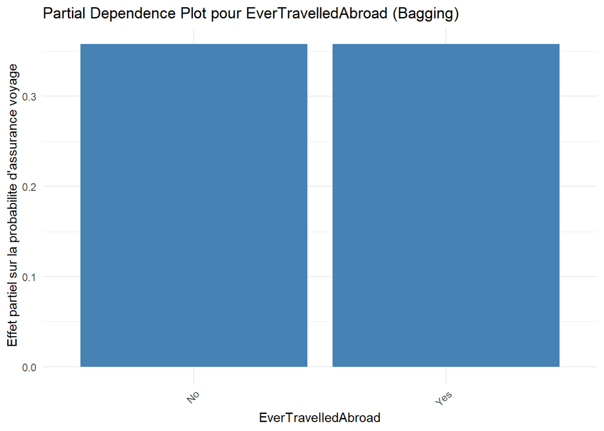

```r
pdp_bagging_categorical <- function(models, var_name, data) {
  # Obtenir les niveaux uniques
  levels <- sort(unique(data[[var_name]]))

  # Créer le dataframe pour stocker les résultats
  pdp_result <- data.frame(
    x = levels,
    y = numeric(length(levels))
  )
  names(pdp_result)[1] <- var_name

  # Pour chaque niveau
  for (i in seq_along(levels)) {
    # Créer une copie des données avec la variable fixée
    temp_data <- data
    temp_data[[var_name]] <- levels[i]

    # Prédire avec chaque modèle
    predictions <- lapply(models, function(model) {
      predict(model, temp_data, type = "prob")[, 2]
    })

    # Moyenner les prédictions de tous les modèles
    avg_pred <- rowMeans(do.call(cbind, predictions))

    # Stocker le résultat
    pdp_result$y[i] <- mean(avg_pred)
  }

  return(pdp_result)
}


# Créer les PDP pour les variables catégorielles importantes

for (var in intersect(top_vars, categorical_vars)) {
  pdp_data <- pdp_bagging_categorical(bagg_cart, var, training_set)

  p <- ggplot(pdp_data, aes_string(x = var, y = "y")) +
    geom_bar(stat = "identity", fill = "steelblue") +
    theme_minimal() +
    theme(axis.text.x = element_text(angle = 45, hjust = 1)) +
    labs(title = paste("Partial Dependence Plot pour", var, "(Bagging)"),
         y = "Effet partiel sur la probabilite d'assurance voyage",
         x = var)

  print(p)
}
```

La variable EverTravelledAbroad n’apporte pas de gain discriminant significatif dans le modèle bagging, la probabilité prédite reste stable quelle que soit la modalité. Cela reflète un effet marginal ou redondant vis-à-vis d’autres variables plus prédictives.

## 3.3 **Méthodes d’Ensemble : Random Forest**

### 3.3.1 **Construction d’une forest d’arbres**

```r
set.seed(123)
m0_rf <- randomForest(
  TravelInsurance ~ Age + AnnualIncome + Employment_Type +
                    GraduateOrNot + ChronicDiseases + FrequentFlyer + EverTravelledAbroad,
  data = training_set,
  ntree = 50,            # Nombre d'arbres dans la forêt
  nodesize = 5,          # Nombre minimal d'observations dans chaque feuille
  mtry = 2,              # Nombre de variables tirées à chaque nœud
  importance = TRUE,     # Évaluer l'importance des prédicteurs
  keep.forest = TRUE,    # Conserver la forêt pour les prédictions futures
  do.trace = TRUE        # Afficher des informations pendant l'apprentissage
)
```

```
## ntree      OOB      1      2
##     1:  22.07%  7.14% 48.82%
##     2:  23.51%  8.98% 51.04%
##     3:  23.23%  7.39% 51.41%
##     4:  24.25%  7.16% 54.10%
##     5:  23.88%  7.31% 53.40%
##     6:  23.04%  5.06% 54.53%
##     7:  23.46%  5.94% 54.33%
##     8:  22.77%  4.82% 54.74%
##     9:  23.37%  6.26% 54.11%
##    10:  23.28%  6.73% 53.12%
##    11:  23.47%  6.79% 53.45%
##    12:  22.73%  5.89% 53.00%
##    13:  23.14%  6.37% 53.36%
##    14:  22.78%  5.58% 53.79%
```

[output cut: 36 more lines]

L’évaluation OOB du modèle Random Forest montre une stabilisation de l’erreur globale autour de 21.8 % à partir de 40 arbres, ce qui indique une bonne convergence du modèle. L’erreur est plus faible pour la classe majoritaire, ce qui peut refléter un déséquilibre dans les données ou une prédiction plus aisée des non-souscriptions.

### 3.3.2 **Estimation de la performance en utilisant l’erreur OOB en fonction de mtry**

```r
mtry_values <- c(2, 3, 4, 5, 6, 7)
oob_mtry_results <- data.frame(
  mtry = mtry_values,
  oob_error = numeric(length(mtry_values))
)

set.seed(24)
for (i in seq_along(mtry_values)) {
  cat("Evaluation avec mtry =", mtry_values[i], "\n")

  # Construction du modèle avec différentes valeurs de mtry
  rf_model <- randomForest(
    TravelInsurance ~ Age + AnnualIncome + Employment_Type +
                      GraduateOrNot + ChronicDiseases + FrequentFlyer + EverTravelledAbroad,
    data = training_set,
    ntree = 100,              # Nombre fixe d'arbres pour l'évaluation
    nodesize = 5,             # Valeur fixe pour nodesize
    mtry = mtry_values[i],    # Valeur variable de mtry
    importance = FALSE,
    do.trace = FALSE
  )

  # Stockage de l'erreur OOB
  oob_mtry_results$oob_error[i] <- tail(rf_model$err.rate[, "OOB"], 1)
}
```

```
## Evaluation avec mtry = 2
## Evaluation avec mtry = 3
## Evaluation avec mtry = 4
## Evaluation avec mtry = 5
## Evaluation avec mtry = 6
## Evaluation avec mtry = 7
```

```r
# Affichage des résultats
print(oob_mtry_results)
```

```
##   mtry oob_error
## 1    2 0.2106918
## 2    3 0.2238994
## 3    4 0.2352201
## 4    5 0.2358491
## 5    6 0.2421384
## 6    7 0.2402516
```

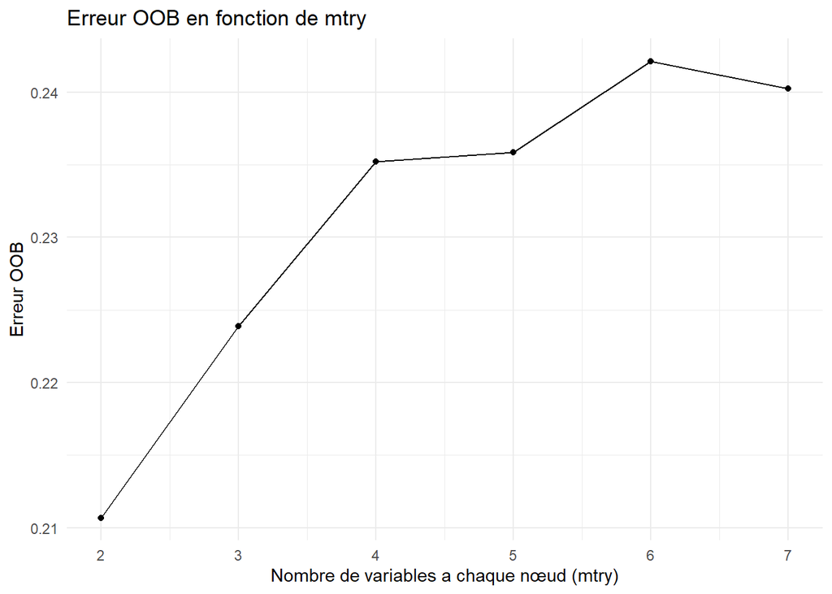

```r
# Graphique de l'erreur OOB en fonction de mtry
ggplot(oob_mtry_results, aes(x = mtry, y = oob_error)) +
  geom_line() +
  geom_point() +
  theme_minimal() +
  labs(title = "Erreur OOB en fonction de mtry",
       x = "Nombre de variables a chaque nœud (mtry)",
       y = "Erreur OOB")
```

```r
# Identification du meilleur mtry selon l'erreur OOB
best_mtry_oob <- mtry_values[which.min(oob_mtry_results$oob_error)]
```

#### 3.3.2.1 **Interprétation du graphique “Erreur OOB en fonction de mtry**

Ce graphique montre comment **l’erreur Out-Of-Bag (OOB)** varie en fonction du **paramètre `mtry`**, c’est-à-dire le **nombre de variables candidates testées à chaque nœud de split** dans la forêt aléatoire.

L’analyse de la variation de l’erreur OOB en fonction du paramètre `mtry` montre que la performance du modèle Random Forest est optimale lorsque `mtry = 2`. Au-delà de cette valeur, l’erreur augmente, ce qui suggère que l’introduction de trop de variables lors de chaque division réduit la capacité du modèle à bénéficier pleinement de la diversité apportée par le bagging. Ainsi, un `mtry` faible favorise une meilleure généralisation du modèle.

Dans la suite, nous allons extraire la valeur optimale de best_mtry_oob, c’est-à-dire le paramètre mtry qui minimise l’erreur OOB. Cette valeur nous servira à déterminer ensuite la taille de nœud (nodesize) la plus adaptée, toujours dans l’objectif de réduire l’erreur OOB.